# 06-GARCH-VaR

Author

Romain CAPLIEZ

# Cours

## Objectifs de la modélisation (G)ARCH

Les séries financières sont caractérisées par 5 faits stylisés :

- Autocorrélation élevée des rendements au carré.
- Rendements non gaussiens :
  - Distribution asymétrie avec une skewness négative
  - Excès de kurtosis indiquant des queues de distribution plus épaisses que celles de la loi normale. Il y a plus grande probabilité pour que des valeurs extrêmes se produisent par rapport à la loi normale.
- Cluster de volatilité : les fortes (faibles) variations de rendements sont généralement suivies par de fortes (faibles) variations de rendements. Cela remets en cause l’hypothèse d’homoscédasticité des modèles économétriques.
- Effets de leviers. IL y a une asymétrie entre l’effet des valeurs passées négatives et l’effet des valeurs passées positives sur la volatilité des cours ou des rendements. Les baisses de cours tendent à engendrer une volatilité supérieure à celle induite par une hausse des cours de même ampleur.
- Les rendements présentent de nombreux phénomènes de saisonnalité (effets weekend, effets janvier…).

Les modélisation ARMA étant des modélisation linéaires et stationnaires ne permettent pas de prendre en compte :

- L’autocorrélation du carré des rendements
- Les cluster de volatilité
- Les queues de distribution épaisses

La modélisation (G)ARCH vise à prendre en compte les variances conditionnelles dépendant du temps. Cette modélisation permet de prendre en compte l’hétéroscédasticité que l’on observe présente dans les modélisations ARMA.

## Modèlisation ARCH

Le principe général de la modélisation ARCH (Autoregressive Conditional Heteroscedastic) proposée par Engle (1982) consiste à supposer que la variance dépend de l’ensemble informationnel dont on dispose. Ainsi cette variance ne va plus être constante, mais va évoluer dans le temps lorsque l’ensemble informationnel va évoluer. La variance va réagir et dépendre de l’évolution de son ensemble informationnel (de son passé ou d’autres variables).

Dans la modélisation $ARCH(q)$, le carré des perturbations (le carré des résidus, donc leur variance) va suivre un processus autorégressif d’ordre $q$. La variance des résidus va dépendre de ses valeurs passées. Les modèles ARCH sont donc des modèles autorégressifs conditionnellement hétéroscédastiques. La variance inconditionnelle de ces modèle va être constante, mais leur variance conditionnelle va dépendre d’un ensemble de variable et de paramètres :

$$\begin{aligned}
&V \left( X_{t+1} \right) = c \\[2ex]
&V \left( X_{t+1} | \mathcal{F}_t \right) = f \left( X_1, X_2, \cdots, X_t; \theta \right)
\end{aligned}$$

On dira donc qu’une série $X_t$ suit un processus $ARCH(1)$ si :

$$\begin{aligned}
X_t &= z_t \sqrt{ht} \\[2ex]
h_t &= \alpha_0 + \alpha_1 X_{t-1}^2
\end{aligned}$$

Où :

- $z_t$ est un bruit blanc fort
- $h_t$ est la variance conditionnelle de $X_t$. Il s’agit d’un processus qui conditionnellement à l’ensemble d’information des valeurs passées de $X_t$ est déterministe et positif.

Cette modélisation permet de décrire l’évolution de la variance conditionnelle de la série $X_t$.

## Modélisation ARMA-ARCH

La modélisation ARCH permet de décrire l’évolution de la variance conditionnelle d’une série. On peut associer cette modélisation avec une autre modélisation qui va décrire l’évolution de la moyenne conditionnelle de la série. Ainsi, on peut définir que la moyenne conditionnelle d’une série $Y_t$ va dépendre de ses valeurs passées et de chocs aléatoires, tandis que sa variance conditionnelle va dépendre des valeurs passées de la variance des résidus.

On peut ainsi décrire une série $Y_t$ par une modélisation $ARMA(p_1,q_1)\text{-}ARCH(q_2)$ dans laquelle, une équation va être dédiée à la modélisation de l’espérance conditionnelle (la valeur que prendre en moyenne la série $Y_t$ conditionnellement l’ensemble d’information disponible). Une deuxième équation va être dédiée à la caractérisation de la variance conditionnelle des résidus (la valeur de la variance sachant l’ensemble d’information disponible) qui va dépendre des valeurs passées de la variance des résidus.

L’idée est que la modélisation ARMA va modéliser (correctement on l’espère) la valeur que prendre en moyenne la série $Y_t$. Cependant cette modélisation ne permet pas de prendre en compte une variance qui ne serait pas constante (Cluster de volatilité). Cette variance non-constante va donc se retrouver dans les résidus (tout ce qui n’est pas modélisé se retrouve dans les résidus). On va donc explicitement intégrer une modélisation de ces résidus qui va explicitement définir que la variance conditionnelle dépend des valeurs passées de la variance des résidus.

$$\begin{aligned}
&Y_t = \mu + \sum_{i=1}^{p_1} \phi_i Y_{t-i} + \sum_{j = 1}^{q_1} \theta_j \varepsilon_{t-j} + \varepsilon_t \\[2ex]
&\varepsilon_t = z_t \sqrt{h_t} \\[2ex]
&h_t = \alpha_0 + \sum_{k=1}^{q_2} \alpha_k \varepsilon_{t-k}^2
\end{aligned}$$

Ici la première équation représente la modélisation ARMA de la moyenne conditionnelle. Puisqu’il existe des cluster de volatilité, on va donc intégrer via l’équation 2 que les résidus de la modélisation ARMA contiennent une partie bruit blanc (aléatoire et non autocorrélée : $z_t$) et une partie qui correspond à l’influence de la variance conditionnelle de la série qui n’a pas pu être modélisée par le modèle ARMA : $\sqrt{h_t}$. La troisième équation indique la forme que prend cette variance conditionnelle. Ici elle est supposée dépendre des $q_2$ valeurs passées de la variance des résidus.

$h_t$ étant une variance, elle doit nécessairement être positive. Ainsi il est nécessaire que : ,

- $\alpha_0 > 0$
- $\alpha_k \geq 0, \hspace{0.2cm} k=1,\cdots , q_2$

Il faut noter que la modélisation de l’espérance conditionnelle peut se faire par tout modèle permettant de modéliser cette moyenne conditionnelle. Il n’est pas nécessaire que ce soit un modèle ARMA. L’avantage de la modélisation ARMA est quelle ne nécessite que de l’information sur la série en elle-même et pas sur d’autres séries.

L’un des grands enjeux de cette modélisation ARCH est de correctement prendre en compte toute la dynamique de la variance conditionnelle de la série et donc de choisir un nombre de retards $q_2$ adapté.

## Modélisation ARCH-GARCH

Il est important de correctement modéliser toute la dynamique de la variance conditionnelle. Or pour ce faire, on peut être amené à imposer une valeur du nombre de retards $q_2$ élevée, ce qui peut poser des problèmes d’estimation. Pour contrer ce problème, Bollerslev (1986) introduit le processus GARCH(p,q) (Generalized ARCH). Ce processus va intégrer directement la dynamique de la variance conditionnelle dans sa modélisation. Ainsi la variance conditionnelle va dépendre de la variance des résidus mais également de ses propres valeurs passées. Intégrer les valeurs passées de la variance conditionnelle permet de réduire le nombre de retards $q_2$ nécessaires à la bonne prise en compte de la dynamique de la série.

On définit le modèle $ARMA(p_1,q_1)\text{-}GARCH(p_2,q_2)$ de la façon suivante :

$$\begin{aligned}
&Y_t = \mu + \sum_{i=1}^{p_1} \phi_i Y_{t-i} + \sum_{j = 1}^{q_1} \theta_j \varepsilon_{t-j} + \epsilon_t \\[2ex]
&\varepsilon_t = z_t \sqrt{h_t} \\[2ex]
&h_t = \alpha_0 + \sum_{k=1}^{q_2} \alpha_k \varepsilon_{t-k}^2 + \sum_{l=1}^{p_2} \beta_l h_{t-l}
\end{aligned}$$

L’équation de la moyenne et la définition des résidus ne change pas. C’est la définition de la dynamique de la variance conditionnelle qui change. On garde toujours que la variance conditionnelle $h_t$ dépend des $q_2$ valeurs passées de la variance des résidus, mais on va rajouter que la variance conditionnelle va également dépendre de ses $p_2$ valeurs passées. La variance conditionnelle va intégrer un processus autorégressif.

La variance étant toujours nécessairement positive, les conditions suivantes doivent être respectées pour garantir cette positivité :

- $\alpha_0 > 0$
- $\alpha_k \geq 0, \hspace{0.2cm} k=1,\cdots , q_2$
- $\beta_l \geq 0, \hspace{0.2cm} l=1,\cdots , p_2$

Cette variance conditionnelle sera asymptotiquement stationnaire au second ordre si :

$$\begin{aligned}
\sum_{k=1}^{q_2} \alpha_k + \sum_{l=1}^{p_2} \beta_l \leq 1
\end{aligned}$$

## Modélisation ARCH-IGARCH

Engle et Bollerslev (1987) introduisent la modélisation IGARCH (Integrated GARCH) afin de prendre en compte la présence d’une racine unitaire dans la variance conditionelle. Dans ce cas, un choc sur la variance conditionnelle aura des effets persistants dans le temps. Il n’y a pas de retour à la moyenne suite à un choc sur la variance conditionnelle.

On définit le modèle $ARMA(p_1,q_1)\text{-}IGARCH(p_2,q_2)$ de la façon suivante :

$$\begin{aligned}
&Y_t = \mu + \sum_{i=1}^{p_1} \phi_i Y_{t-i} + \sum_{j = 1}^{q_1} \theta_j \varepsilon_{t-j} + \epsilon_t \\[2ex]
&\varepsilon_t = z_t \sqrt{h_t} \\[2ex]
&h_t = \alpha_0 + \sum_{k=1}^{q_2} \alpha_k \varepsilon_{t-k}^2 + \sum_{l=1}^{p_2} \beta_l h_{t-l}
\end{aligned}$$

Avec :

- $\alpha_0 > 0$
- $\alpha_k \geq 0, \hspace{0.2cm} k=1,\cdots , q_2$
- $\beta_l \geq 0, \hspace{0.2cm} l=1,\cdots , p_2$
- $\sum_{k=1}^{q_2} \alpha_k + \sum_{l=1}^{p_2} \beta_l = 1$

La dernière condition indique qu’un choc aura un effet permanent sur la variance conditionnelle. Il n’y aura pas de retour à la moyenne.

## Modélisation ARMA-GARCH asymétriques

Dans la modélisation d’un processus GARCH, la réponse de la volatilité future aux variations de prix (ou de la variable $Y_t$) va dépendre uniquement de l’ampleur de ces variations et non pas de leur signe. Or, il est connu que les séries financières sont caractérisées par des effets de leviers et de réponse asymétrique aux chocs. Ainsi, il est commun que la volatilité des variations de prix soit plus fortement impactée par des chocs négatifs que positifs.

Les processus GARCH asymétriques vont étendre les processus GARCH pour intégrer de l’asymétrie (non-linéarité) dans la réponse de la volatilité.

### Modélisation ARMA-EGARCH

Nelson (1991) introduit la modélisation de processus EGARCH (Exponential GARCH). Cette modélisation va lever les contraintes de positivité que l’on retrouve dans les processus GARCH grâce à l’utilisation de la fonction exponentielle. Le processus EGARCH va introduire à la fois un effet de signe (asymétrie) et un effet d’amplitude :

- Effet de signe (Asymétrie) : La présence d’asymétrie indique que seul un choc positif ou négatif sur les rendements (série $Y_t$) va faire augmenter la volatilité conditionnelle. Dans le cas le plus classique, un choc négatif sur les rendements va faire augmenter la variance conditionnelle, tandis qu’un choc positif va la faire diminuer. On parlera d’asymétrie lorsqu’un choc positif ou négatif ont le même effet sur les rendements et seul la magnitude (la variance) du choc va compter.
- Effet d’amplitude : La volatilité conditionnelle va dépendre de l’écart entre le choc de rendements observé et la moyenne supposée des chocs. Plus cet écart sera élevé, plus la variance conditionnelle sera impactée.

On définit le modèle $ARMA(p_1,q_1)\text{-}EGARCH(p_2,q_2)$ de la façon suivante :

$$\begin{aligned}
&Y_t = \mu + \sum_{i=1}^{p_1} \phi_i Y_{t-i} + \sum_{j = 1}^{q_1} \theta_j \varepsilon_{t-j} + \epsilon_t \\[2ex]
&\varepsilon_t = z_t \sqrt{h_t} \\[2ex]
&log(h_t) = \alpha_0 + \sum_{k=1}^{q_2} \alpha_k z_{t-k} + \sum_{m=1}^{q_2} b_m \left( \left| z_{t-m} \right| - E \left[ \left| z_{t-m} \right| \right]\right) + \sum_{l=1}^{p_2} \beta_l log(h_{t-l})
\end{aligned}$$

Ici, on ne modélise plus la variance conditionnelle par rapport à la variance des chocs sur les rendements (sur la série $Y_t$). On modélise la volatilité conditionnelle par rapport aux chocs sur les rendements directement : $z_t$. Il s’agit de la partie des rendements qui n’est pas prévue par la modélisation de la moyenne conditionnelle.

Les paramètres $\alpha_k$ vont représenter les effets de signe. Dans le cas le plus simple où $q_2=1$, si $\alpha_1 = 0$, alors il n’y a pas d’asymétrie dans la réponse de la volatilité conditionnelle à un choc sur les rendements à la période passée. La volatilité conditionnelle va répondre de la même manière selon si le choc est positif ou négatif. Dans le cas où $\alpha_1 < 0$, alors on a un effet d’asymétrie négatif : effet de levier. La volatilité conditionnelle va augmenter suite à un choc négatif sur les rendements et diminuer suite à un choc positif. Dans le cas où $\alpha_i > 0$ alors on a une asymétrie positive. Un choc positif sur les rendements aura un effet positif sur la volatilité conditionnelle. Un choc négatif aura un effet négatif.

Les paramètres $b_m$ représentent les effets d’amplitude. Plus le choc sur les rendements va être grand (plus la valeur absolue du choc va s’éloigner de la valeur moyenne des chocs), plus l’impact sur la volatilité conditionnelle va être importe (si $b_1>0$). Ces paramètres sont similaires aux paramètres $\alpha_k$ de la modélisation GARCH. Ces paramètres indiquaient la réponse de la volatilité conditionnelle suite à une augmentation de la variance des chocs passés sur les rendements. Dans le processus EGARCH, on ne regarde pas la volatilité des chocs de rendements passés, mais à quel point ces chocs sont éloignés de leur moyenne, mais le principe est très similaire (puisque la variance indique à quel point on s’éloigne de la moyenne).

La valeur de $E \left[ \left| z_{t-m} \right| \right]$ va dépendre de la loi supposée de $z_t$ (voir infra).

Ce modèle présente l’avantage de ne pas avoir de contraintes de positivité sur ses coefficients.

### Modélisation ARMA-GJR-GARCH

Glosten et al (1993) proposent la modélisation GJR-GARCH qui va introduire une variable binnaire afin de différencier explicitement l’immpact d’un choc négatif ou positif sur la volatilité conditionnelle.

On définit le modèle $ARMA(p_1,q_1)\text{-}IGARCH(p_2,q_2)$ de la façon suivante :

$$\begin{aligned}
&Y_t = \mu + \sum_{i=1}^{p_1} \phi_i Y_{t-i} + \sum_{j = 1}^{q_1} \theta_j \varepsilon_{t-j} + \epsilon_t \\[2ex]
&\varepsilon_t = z_t \sqrt{h_t} \\[2ex]
&h_t = \alpha_0 + \sum_{i=1}^{q_2} \left( \alpha_i \varepsilon_{t-i}^2 + \gamma_i \mathbb{I}_{\varepsilon_{t-i}< 0} \varepsilon_{t-i}^2 \right) + \sum_{i=1}^{p_2} \beta_i h_{t-i} \\[2ex]
&\mathbb{I}_{\varepsilon_{t-i}<0} =
\begin{cases}
1 \hspace{0.2cm} \text{si} \hspace{0.2cm} \varepsilon_{t-i} < 0 \\[2ex]
0 \hspace{0.2cm} \text{si} \hspace{0.2cm} \varepsilon_{t-i} \geq 0
\end{cases}
\end{aligned}$$

La modélisation GJR-GARCH introduit une variable binaire qui va prendre la valeur 1 si le choc sur les rendements passé est négatif et 0 s’il est nul ou positif. Cela permet d’introduire un effet différencié selon le signe du choc de rendements. Ainsi, dans le cas simple où $q_2 =1$, si le choc sur les rendements passé est négatif, alors l’augmentation de la volatilité des rendements de 1, entraînera une augmentation de la volatilité conditionnelle de $\alpha_1$. En revanche, si le choc sur les rendements passé est négatif, alors l’augmentation de la volatilité des rendements de 1, entraînera une augmentation de la volatilité conditionnelle de $\alpha_1 + \gamma_1$. Si ces deux coefficients sont positifs alors un choc de rendements négatif aura un impact plus important qu’un choc de rendements positif.

On retrouve les contraintes de positivité dans cette spécification puisque l’on modélise de nouveaux la variance conditionnelle.

## Tester la présence d’effets ARCH

Utiliser une modélisation de type ARCH ne se justifie que si la série $Y_t$ est caractérisée par la présence d’effets ARCH. Pour tester la présence de ces effets ARCH, on peut utiliser les tests d’autocorrélation classique sur les rendements au carré ou bien utiliser le test ARCH-LM.

### Test de Ljung-Box sur les rendements au carré

Ce test vise à déterminer si les rendements au carré (donc leur variance si la moyenne est égale à 0) sont autocorrélés, donc s’ils dépendent de leur valeur passée.

A partir de la série des rendements $Y_t$, on va créer la série des rendements au carré $Y_t^2$.

On teste l’hypothèse nulle qu’il n’y a pas d’autocorrélation à l’ordre $K$ entre nos rendements au carré (la variance des rendements ne dépend pas de ses valeurs passées).

$$\begin{cases}
H_0 : \rho_1 = \cdots = \rho_{K} \\[2ex]
H_1 : \exists \hspace{0.2cm} \rho_k \neq 0
\end{cases}$$

La statistique de test est donnée par :

$$\begin{aligned}
LB(K) = T(T+2) \sum_{k=1}^K \frac{\hat{\rho}_{k}^2}{T-k} \sim \chi^2(K)
\end{aligned}$$

où $\hat{\rho}_k$ désigne l’autocorrélation empirique des rendements au carré :

$$\begin{aligned}
\hat{\rho}_k = \frac{\sum_{t=k+1}^T \left( X_t^2 - \bar{X}^2 \right) \left( X_{t-k}^2 - \bar{X}^2 \right) / \left( T-k \right)}{\sum_{t=k+1}^T \left( X_t^2 - \bar{X}^2 \right)^2 / T}
\end{aligned}$$

La règle de décision est la suivante :

- Si $LB(K) \geq \chi^2(K)$, alors on rejette l’hypothèse nulle de non-autocorrélation des rendements au carré. Nos rendements au carré (la variance des rendements) dépendent de leur valeur passé au moins jusqu’à l’ordre $K$. Il y a donc possiblement de la présence d’effets ARCH dans nos rendements qu’il va falloir modéliser explicitement.
- Si $LB(K) <\chi^2(K)$, alors on ne peut pas rejeter l’hypothèse nulle de non-autocorrélation des rendements au carré. Il semblerait que nos rendements au carré (la variance des rendements) ne dépendent pas de leur valeur passé au moins jusqu’à l’ordre $K$. Il n’y a vraisemblablement pas d’effets ARCh dans nos rendements. Une modélisation de l’espérance conditionnelle est donc suffisante.

### Test ARCH-LM

Le test ARCH vise à déterminer si une série suit un processus Autorégressif Conditionnellement Hétéroscédastique (ARCH) ou non. Ce test est un test LM qui se base sur l’estimation d’une régression auxiliaire. La première étape consiste à modéliser l’espérance conditionnelle de notre série des rendements (par une modélisation ARMA par exemple). On récupère ensuite la série des résidus $\hat{\varepsilon}_t$.

On estime la régression suivante :

$$\hat{\varepsilon}_t^2 = \alpha_0 + \sum_{i=1}^l \alpha_i \hat{\varepsilon}_{t-i}^2$$

On calcule ensuite le coefficient de détermination $R^2$ de cette régression.

On teste l’hypothèse nulle d’absence d’hétéroscédasticité conditionnelle :

$$\begin{cases}
H_0 : \alpha_i = 0 \hspace{0.3cm} \forall \hspace{0.2cm} i = 1, \cdots, l \\[2ex]
H_1 : \exists \hspace{0.2cm} \alpha_i \neq 0
\end{cases}$$

On calcule la statistique :

$$LM = TR^2 \sim \chi^2(l)$$

La règle de décision est la suivante :

- Si $LM \geq \chi^2(l)$ (ou $p.value \leq 0.05$), on rejette $H_0$. Les résidus n’ont pas une variance conditionnelle constante et sont donc conditionnellement hétéroscédastiques. Il est nécessaire de modéliser la variance conditionnelle de la série.
- Si $LM < \chi^2(2p)$ (ou $p.value >0.05$), on ne peut pas rejeter $H_0$. Les résidus ont une variance conditionnelle constante et sont donc conditionnellement homoscédastiques. La modélisation de l’espérance conditionnelle est suffisante.

## Estimation des Modèles type ARCH

Les modèles de type ARCH sont estimés par le principe du Pseudo Maximum de Vraisemblance (QLME). Ce principe consiste à appliquer la méthode du Maximum de Vraisemblance (MLE) en supposant que les résidus suivent une certaine, même si dans la réalité cette hypothèse n’est pas vérifiée.

L’estimateur MLE n’a pas de fondement si l’on fait une erreur sur la distribution postulée. L’idée générale de l’estimateur QMLE consiste à démontrer que l’estimateur du Maximum de Vraisemblance obtenu peut être convergent, même en cas d’erreur sur la loi postulée, si la vraie loi des résidus appartient à la même classe de loi que celle postulée.

Classiquement, on va postuler que les résidus suivent une loi normale. Cette loi est très simple et facile à implémenter. Mais on peut appliquer le principe du GMLE à d’autres lois pour ainsi prendre en compte des caractéristiques que ne peut prendre en compte la loi normale comme par exemple :

- **Loi de Student** pour modéliser des queues de distribution plus épaisses
- **Loi de Student dysimétrique standardisée (skewed-Student)** pour modéliser des distribution asymétriques avec des queues de distribution plus épaisses.
- **Loi GED (Generalized Error Distribution)** pour modéliser des queues de distributions plus épaisses.

## Validation du modèle ARCH sélectionné

La première étape lors d’une modélisation ARCH à tester la présence d’effets ARCH dans notre série au carré ou bien dans les résidus au carré. Pour cela il faut modéliser correctement l’espérance conditionnelle de la série $Y_t$ (Voir procédure dans le chapitre 03-ARIMA). On applique ensuite le test ARCH-LM sur les résidus au carré de cette modélisation.

En cas de présence d’effets ARCH, on commence par estimer simple processus ARCH(1) (ou GARCH(1,1)) en supposant que les résidus suivent une loi normale. L’idée est de tester si la modélisation la plus simple permet de prendre en compte toutes les caractéristiques de la série.

Pour tester la validité de ce modèle, on commence d’abord par vérifier si les contraintes de positivité sont vérifiées dans notre modèle estimé. Si ce n’est pas le cas, il faut changer de modélisation.

On teste ensuite s’il existe encore de l’autocorrélation au sein de nos résidus standardisés $\hat{z}_t = \frac{X_t}{\sqrt{h_t}}$. Si tel est le cas, c’est que notre modélisation de la moyenne conditionnelle n’est pas satisfaisante.

On continue par tester s’il existe encore des effets ARCH dans les résidus standardisés en appliquant le test ARCH sur ces résidus. S’il existe encore des effets ARCH, il faut réestimer le modèle en augmentant l’ordre $p_2$ et/ou $q_2$. Dans ce cas on repart à la première étape de validation.

Il faut ensuite tester s’il existe de l’asymétrie dans la réponse de la variance conditionnelle suite à des chocs positifs ou négatifs. Pour cela on applique les tests d’asymétrie de Engle et Ng (1993). Il s’agit de 3 tests (biais de signe négatif, biais de signe positif, test joint de biais de signe) dont l’hypothèse nulle est l’absence de biais dans les résidus standardisés. Si on trouve la présence d’asymétrie grâce à l’un de ces tests, cela signifie que l’on ne prend pas en compte toutes les caractéristiques de la série. Il faut donc réestimer un modèle prenant en compte ces asymétries (ou augmenter les ordres du modèle si on estime déjà un modèle à asymétrie).

Enfin, si jamais il apparaît que la série (et donc les résidus standardisés) présente des signe de non-normalité, alors on peut estimer le modèle en prenant une autre loi supposée suivie par les résidus.

Cela peut donner un certain nombre de modèles à tester. On peut comparer les différents modèles grâce aux critères d’informations pour choisir celui qui va le mieux représenter les données tout en gardant une certaine parcimonie dans le nombre de paramètres estimés.

## Définition de la Value at Risk (VaR)

La Value at Risk est une mesure du risque introduite par Jorion (2007) qui correspond au montant des pertes qui ne devraient pas être dépassées pour un niveau de confiance donné sur un horizon temporel donné. Elle correspond à une perte potentielle ou maximale qui ne devrait être atteinte qu’avec une probabilité donnée sur un horizon donné.

La distribution statistique de la VaR va reposer sur 3 éléments :

- La distribution des profits et des pertes (P&L) du portefeuille ou de l’actif.
- Le niveau de confiance $1-\alpha$. Généralement on prend $\alpha=1\%$.
- L’horizon du risque. On considérera ici $t=1$.

La VaR définie pour un taux de couverture $\alpha \%$ correspond au quantile d’ordre $\alpha$ de la distribution des profits et des pertes associée à la détention d’un actif ou d’un portefeuille d’actif sur une période donnée.

Pour résumer, la VaR n’est qu’un quantile particulier de la distribution des profits et des pertes.

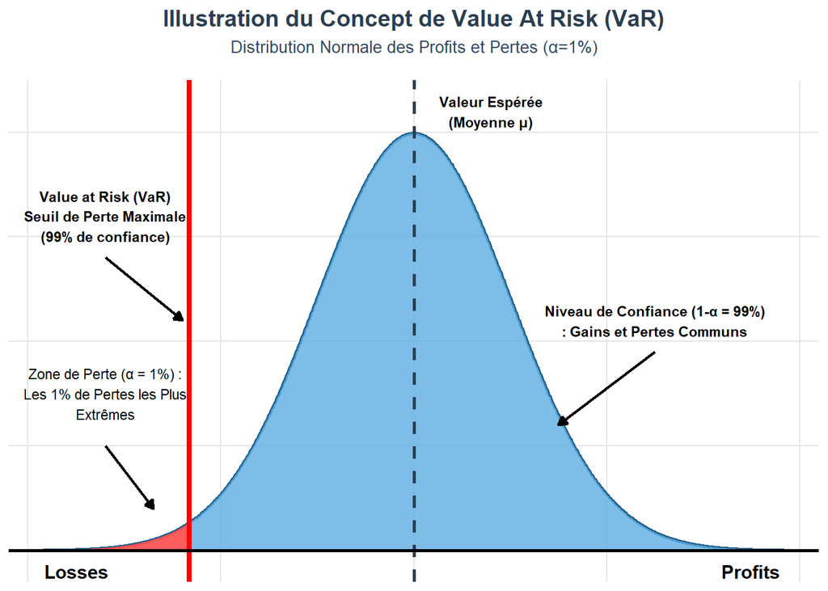

Si l’on note $R_t$ les rendements sur un horizon donné, on note leur fonction de densité :

$$\begin{aligned}
F_{R_t}(X) = Pr(R_t \leq X)
\end{aligned}$$

Pour un taux de couverture $\alpha \%$, la VaR correspond à l’opposée du fractile d’ordre $\alpha$ de la distribution des rendements. On prend l’opposé car par convention on indique la VaR de manière positive.

$$\begin{aligned}
VaR_t (\alpha) = - F_{R_t}^{-1} (\alpha)
\end{aligned}$$

Par définition, la probabilité d’observer une perte supérieure à la VaR sur l’horizon de détention est égale au taux de couverture :

$$\begin{aligned}
Pr[R_t < -VaR_t (\alpha)] = \alpha
\end{aligned}$$

Cette définition de la VaR nous donne une VaR marginale (non-conditionnelle). Cette Value at Risk est constante. Cela suppose donc que le risque et la volatilité sont constants dans le temps. Or ce n’est pas forcément le cas. On peut donc calculer une mesure de risque conditionnelle à un ensemble d’information afin que cette mesure s’ajuste à l’ensemble d’information.

Cette mesure est appelée VaR conditionnelle. Pour un taux de couverture $\alpha$, la VaR conditionnelle à un ensemble d’information $I_t$, notée $VaR_t(\alpha|I_t) = F_{R_t}(\alpha |I_t)$, correspond à l’opposé du fractile d’ordre $\alpha$ de la distribution conditionnelle des rendements.

$$\begin{aligned}
VaR_t (\alpha |I_t) = - F_{R_t}^{-1} (\alpha |I_t)
\end{aligned}$$

Où $F_{R_t}^{-1} (\alpha |I_t)$ correspond à la fonction de répartition conditionnelle de la fonction de densité conditionnelle $f_{R_t}^{-1} (\alpha |I_t)$

On peut supposer que la densité conditionnelle varie elle aussi dans le temps, mais généralement on va la supposer constante (le processus générateur des donnée reste constant dans le temps).

## Estimation de la VaR

### Volatilité constante dans le temps

Si l’espérance conditionnelle des rendements est nulle ($\mu_{t+1|t} = 0$), alors le calcul de la VaR ne nécessite qu’un estimateur de la variance des rendements. A partir de là, si la volatilité des rendements est constante dans le temps : $\sigma_{t+1|t} = \sigma$, alors il suffit d’estimer l’écart-type des rendements puis de trouver le $\alpha$ quantile de la loi que sont supposées suivre les rendements.

Si l’on suppose que les rendements suivent une loi normale, on peut estimer la VaR Variance-Covariance avec la formule suivante :

$$\begin{aligned}
-\left( \mu_r + \sigma_r \times \Theta^{-1}(\alpha) \right)
\end{aligned}$$

Où :

- $\mu_r$ est la moyenne empirique des rendements
- $\sigma_r$ est l’écart-type empirique des rendements
- $\Theta^{-1}(\alpha)$ est le quantile $\alpha$ de la loi normale.

Si nos rendements sont caractérisés par des queues de distribution plus épaisse, on peut estimer une VaR avec une loi de Student :

$$\begin{aligned}
- \left( \mu_r - \sigma_r \times \sqrt{\frac{v-2}{v}} \times G^{-1}(v;\alpha) \right)
\end{aligned}$$

où :

- $\mu_r$ est la moyenne empirique des rendements
- $\sigma_r$ est l’écart-type empirique des rendements
- $v$ est le paramètre de forme de la loi de student suivie par les résidus
- $G^{-1}(v;\alpha)$ est le quantile $\alpha$ de la loi de Student de paramètre $v$.

Si la distribution empirique présente des queues de distributions épaisses mais n’est pas si éloignée de la loi normale, on peut utiliser l’approximation de Cornish-Fisher pour modéliser ces queues de distribution plus épaisses :

$$\begin{aligned}
&-\left( \mu_r + \sigma_r \times \kappa^{-1}_\alpha\right) \\[2ex]
&\kappa_\alpha^{-1} = a + \frac{a^2 - 1}{6}S + \frac{a^3 - 3a}{24}K + \frac{2a^3 - 5a}{36}S^2 \\[2ex]
&a = \Theta^{-1}(\alpha)
\end{aligned}$$

Où :

- $\mu_r$ est la moyenne empirique des rendements
- $\sigma_r$ est l’écart-type empirique des rendements
- $\Theta^{-1}(\alpha)$ est le quantile $\alpha$ de la loi normale.
- $S$ est le coefficient de skewness de la série

-$K$ est le coefficient de kurtosis de la série

### Volatilité non-constante dans le temps

Si la volatilité n’est pas constante, on peut calculer l’écart-type des rendements sur une fenêtre glissante, c’est à dire calculer l’écart-type sur les $x$ premiers jours, puis décaler la fenêtre de 1 jour (au début et à la fin), calculer l’écart-type etc… Cela permet d’avoir une mesure de la volatilité qui dépend du temps. Dans ce cas, il faut trouver le $\alpha$ quantile de la loi supposée suivie par les rendements pour chaque période de temps. Les formules vu dans le cas où la volatilité est constante restent applicables. Seulement la moyenne et l’écart-type vont varier au fil du temps.

Une autre solution consiste à estimer des modèles calculant la volatilité conditionnelle de la série puis à trouver le $\alpha$ quantile associé à la loi de distribution que sont supposés suivre les rendements

Supposons que les rendements suivent un processus AR(1)-GARCH(1,1) :

$$\begin{aligned}
R_t &= \rho R_{t+1} + \varepsilon_t \\[2ex]
\varepsilon_t &= z_t \sqrt{h_t} \\[2ex]
h_t &= \alpha_0 + \alpha_1 \varepsilon_{t-1}^2 + \beta h_{t-1}
\end{aligned}$$

Dans ce cas, on sait que l’espérence et la variance conditionnelle en $t+1$ s’écrit :

$$\begin{aligned}
E \left[ R_{t+1} |I_t \right] &= \rho R_t \\[2ex]
V \left[ R_{t+1}|I_t \right] &= V \left[ \varepsilon_{t+1} |I_t \right] = \alpha_0 + \alpha_1 \varepsilon_{t-1}^2 + \beta h_t
\end{aligned}$$

Si on ajoute l’hypothèse que les résidus standardisés suivent une loi normale centrée réduite : $z_t |I_t \sim \mathcal{N}(0,1)$, alors on peut prévoir la VaR à l’horizon d’un jour avec la formule suivante :

$$\begin{aligned}
VaR_{t+1|t} (1-\alpha) &= -E \left[ R_{t+1} |I_t \right] - \sqrt{V \left[ R_{t+1}|I_t \right]} \times \Theta^{-1} (\alpha) \\[2ex]
VaR_{t+1|t} (1-\alpha) &= -\rho R_t - \sqrt{\alpha_0 + \alpha_1 \varepsilon_{t-1}^2 + \beta h_t} \times \Theta^{-1} (\alpha)
\end{aligned}$$

Avec $\Theta^{-1} (\alpha)$ la fonction de répartition de la loi normale pour le quantile $\alpha$.

De manière plus générale on peut calculer la VaR avec la formule suivante :

$$\begin{aligned}
VaR_{t+1|t} (1-\alpha) &= - \left( \mu_t + z_\alpha \sqrt{h_t} \right)
\end{aligned}$$

Où :

- $\mu_t$ est la moyenne conditionnelle des rendements à la période $t$
- $h_t$ est la volatilité conditionnelle des rendements à la période $t$
- $z_\alpha$ est le $\alpha$-quantile (négatif) de la loi de probabilité supposée suivie par les résidus.

## Tester la validité de la VaR (backtesting)

### Problématique des tests sur la VaR

Les manières de calculer la VaR sont nombreuses (bien plus que celles abordées ici) et les valeurs trouvées dépendent énormément du modèle utilisé. L’estimation de différentes VaR conduit à des estimations différentes du risque et des implication spour les institutions financières.

IL devient donc nécessaire d’avoir une méthode pour comparer l’efficacité des différents modèles.

De manière générale, on évalue la qualité de prévision d’une grandeur économique en comparant sa vraie réalisation (ex-post) à la valeur prédite par le modèle (ex-ante). On calcule alors une erreur de prévision qui permet de construire des critères d’évaluation (RMSE, MAE…). On peut également construire des tests statistiques où l’hypothèse nulle est que les deux modèles présentent des capacités prédictives similaires.

Le problème qui se pose est que ces méthodes ne peuvent être utilisées que si la réalisation ex-post de la variable d’intérêt est réellement observable (de manière objective), ou bien s’il existe une variable proxy de cette variable d’intérêt permettant une comparaison.

Or la construction d’une telle variable objective ou de proxy est impossible.

### Principe du Backtesting

Plusieurs tests ont été proposés afin d’évaluer la qualité de prévision d’une VaR. Ils sont pour la plupart fondés sur les occurences de violation. On va généralement tester statistiquement les deux principales hypothèses que le modèle de mesure du risque doit satisfaire :

- L’hypothèse de couverture non conditionnelle (UC)
- L’hypothèse d’indépendance des violations (IND)

On définit la violation comme une situation dans laquelle on observe ex-post (après coup) une perte plus importante en valeur absolue que la valeur de la VaR prévue ex-ante (précédemment). (Rappel que la VaR est positive il faut donc prendre l’opposée des rendements pour comparer les pertes avec la VaR).

$$\begin{aligned}
L_{t+1}^{\Delta} = -R_{t+1} > VaR_{t+1|t}(1-\alpha)
\end{aligned}$$

A partir de là on peut définir une variable binaire (dichotomique / dummy) associée à l’occurence d’une violation appelée **“Hit Function”**. Elle prend la valeur 1 lorsque la perte est supérieure à la VaR et la valeur 0 sinon.

$$\begin{aligned}
HIT_{t+1} = 1_{\left( L_{t+1}^{\Delta} > VaR_{t+1|t}(1-\alpha)\right)}
\end{aligned}$$

Cette variable va permettre d’identifier les périodes pour lesquelles on observe une perte plus importante que la VaR (donc que la perte maximale probable).

C’est sur cette variable que l’on va généralement appliquer des tests statistiques pour tester l’hypothèse de couverture conditionnelle et l’hypothèse d’indépendance.

L’hypothèse de couverture non conditionnelle est l’hypothèse que le nombre de violations observées ex-post est effectivement égal au taux de couverture $\alpha$. Il faut que la probabilité que se réalise ex-post une perte en excès par rapport à la VaR anticipée ex-ante soit précisément égale au taux de couverture $\alpha$.

$$\begin{aligned}
Pr [HIT_t (\alpha) = 1] = E [HIT_t (\alpha)]= \alpha
\end{aligned}$$

Si la probabilité de violation est significativement inférieure au taux de couverture $\alpha$, cela traduit une surestimation de la VaR et donc du risque, conduisant par conséquent à peu de violations. La VaR est dite **conservative**.

L’hypothèse d’indépendance indique que les violations de la VaR observées à deux dates différentes pour un même taux de couverture sont indépendamment distribuées :

$$\begin{aligned}
corr \left( HIT_t(\alpha), HIT_{t-k} (\alpha) \right) = 0 \hspace{0.2cm} \forall \hspace{0.2cm} k \neq0
\end{aligned}$$

L’observation des violations de la VaR n’apporte aucune information sur les violations contemporaines ou futures. Cette hypothèse implique donc qu’il ne doit pas y avoir de cluster de violations. il ne faut pas que les violations s’enchaînent en période de crises et n’existent pas en périodes calmes.

Ces deux hypothèses de validité de la VaR sont indépendentes l’une de l’autre. La validité ou le rejet de l’une de ces hypothèses ne donne pas d’indications sur la validité ou le rejet de l’autre hypothèse. Ainsi, si la VaR ne satisfait pas à l’une ou l’autre des hypothèses, elle doit être considérée comme non valide (Christoffersen, 1998).

Finalement, on va qualifier de **couverture conditionnelle** la situation qui prévaut lorsque la prévision de la VaR satisfait les 2 hypothèses : CC = UC + IND.

Sous l’hypothèse jointe de couverture conditionnelle, la fonction HIT est identiquement et indépendament distribuée et doit suivre une loi de Bernoulli de paramètre $\alpha$ :

$$\begin{aligned}
HIT_t (\alpha) \sim \mathcal{B}(\alpha)
\end{aligned}$$

De nombreux tests ont été proposés pour tester les hypothèses UC, IND et CC. La difficulté majeure consiste à spécifier correctement la forme de la dépendance des processus $HIT_t$ sous H1.

**ATTENTION** : les tests de backtesting doivent toujours se faire sur un **échantillon out of sample**. Il faut couper son échantillon en 2 :

- Le premier pour estimer la VaR (les paramètres du modèle)
- Le second pour effectuer les tests de backtesting en ayant calculer la VaR avec les paramètres trouvés grâce au premier échantillon.

Il faut au minimum 250 observations dans chaque échantillon.

### Test de Kupiec (Test UC)

Kupiec (1995) propose un test de couverture non-conditionnelle (UC).

On considère une séquence de T prévisions successives de la VaR et on note $N$ le nombre de violations associées :

$$\begin{aligned}
N = \sum_{t=1}^T HIT_t (\alpha)
\end{aligned}$$

Le rapport $\frac{N}{T}$ définit la fréquence empirique des violations (aussi appelé **failure rate**).

Sous l’hypothèse de couverture non-conditionnelle (UC), le failure rate constitue un estimateur convergent du taux de couverture $\alpha$ (en moyenne sur de nombreux échantillons il converge vers la valeur $\alpha$).

Sous l’hypothèse d’indépendance des violations (IND), alors le nombre total de violations suit une loi Binomiale.

$$\begin{aligned}
&N \sim \mathcal{Bi}[T;\alpha] \\[2ex]
&E(N) = \alpha T \\[2ex]
&V(N) = \alpha (1 - \alpha)T
\end{aligned}$$

Lorsque T va être suffisament grand on va pouvoir approximier la loi Binomiale par une loi Normale.

A partir de ces considérations, on va tester :

$$\begin{cases}
H0 : E[HIT_t(\alpha)] = \alpha \\[2ex]
H1 : E[HIT_t(\alpha)] \neq \alpha
\end{cases}$$

La statistique de test est une statistique LR (ratio de vraisemblance) et est :

$$\begin{aligned}
LR_{UC} = -2 log \left[ \left(1-\alpha\right)^{T-N} \times \alpha^N \right] + 2 log \left[ \left(1- \left(\frac{N}{T}\right)\right)^{T-N} \times \left( \frac{N}{T} \right) ^N \right] \sim \chi^2(1)
\end{aligned}$$

Il faut faire attention car ce test suppose que les violations sont indépendantes. La règle de décision est la suivante :

- Si $LR_{UC} \geq \chi^2(1)$, on rejette l’hypothèse nulle de couverture non-conditionnelle. La VaR est soit trop stricte, soit pas assez. Le risque n’est pas correctement estimé. Cette mesure de la VaR n’est pas valide, il faut changer de modèle.
- Si $LR_{UC} < \chi^2(1)$, on ne peut pas rejeter l’hypothèse nulle de couverture non-conditionnelle. La VaR est semble correctement calibrer du point de vue du nombre de violations.

### Test de Christoffersen

#### Idée du test

Christoffersen (1998) propose de modéliser la non efficience de la VaR par une chaîne de Markov. L’idée est de modéliser les états dans lesquels la variable HIT peut se trouver et les probabilités de changer d’état.

Les hypothèses UC, IND et CC vont alors correspondre à des restrictions sur les paramètres qui peuvent être testées avec des statistiques LR.

On suppose que la dépendance dans le processus des violation $HIT_t(\alpha)$ peut être modélisée par une chaîne de Markov d’ordre 1 avec la matrice des probabilités de transition suivante :

$$\Pi =
\begin{pmatrix}
\pi_{00} & \pi_{01} \\
\pi_{10} & \pi_{11}
\end{pmatrix}$$

Où :

$$\begin{aligned}
\pi_{ij} = Pr \left[ HIT_t(\alpha) = j \hspace{0.2cm} | \hspace{0.2cm} HIT_{t-1}(\alpha) = i \right]
\end{aligned}$$

Avec l’état $O$ correspondant à une non violation et l’état $1$ correspondant à une violation.

Ainsi :

- $\pi_{00}$ mesure la probabilité de ne pas observer de violation en $t$ sachant qu’il n’y a pas eu de violation en $t-1$
- $\pi_{10}$ mesure la probabilité de ne pas observer de violations en $t$ sachant qu’il y a eu une violation en $t-1$
- $\pi_{01}$ mesure la probabilité d’observer une violation en $t$ sachant qu’il n’y a pas eu de violation en $t-1$
- $\pi_{11}$ mesure la probabilité d’observer une violation en $t$ sachant qu’il y a pas eu une violation en $t-1$

Par définition, on a : $\pi_{00} = 1 - \pi_{01}$ et $\pi_{10} = 1 - \pi_{11}$.

La matrice de transition est donc :

$$\Pi =
\begin{pmatrix}
1 - \pi_{01} & \pi_{01} \\
1 - \pi_{11} & \pi_{11}
\end{pmatrix}$$

Sous l’hypothèse d’indépendance (IND), la probabilité d’observer une violation à la date $t$ est indépendante de l’état en $t-1$. Ainsi les probabilités deviennent : $\pi_{11} = \pi_{01} = \pi$ et $\pi_{00} = \pi_{10}$. Et la matrice de transition devient :

$$\Pi =
\begin{pmatrix}
1 - \pi & \pi \\
1 - \pi & \pi
\end{pmatrix}$$

Si l’on ajoute l’hypothèse de couverture non conditionnelle (UC), quel que soit l’état du système en $t-1$ (violation ou non en $t-1$), la probabilité d’observer à la date $t$ une violation doit être égale au taux de couverture conditionnel $\alpha$. On a donc

$$\begin{aligned}
\pi_{01} = \pi_{11} = \pi_t = Pr[HIT_t(\alpha) = 1] = \alpha
\end{aligned}$$

Donc sous l’hypothèse de couverture conditionnelle (hypothèse d’indépendance jointe à l’hypothèse de couverture non-conditionnelle), on a la matrice :

$$\Pi_\alpha =
\begin{pmatrix}
1 - \alpha & \alpha \\
1 - \alpha & \alpha
\end{pmatrix}$$

A partir de ces matrices et hypothèses, on peut tester les hypothèses nulles de couverture non-conditionnelle, d’indépendance et même tester l’hypothèse nulle de couverture conditionnelle (aussi appelée efficience conditionnelle).

#### Test de couverture non-conditionnelle (UC)

Le test de couverture non-conditionnelle est le suivant :

$$\begin{cases}
H0^{UC} : Pr[HIT_t(\alpha) = 1] = \alpha : \text{Couverture non conditionnelle respectée} \\[2ex]
H1^{UC} : Pr[HIT_t(\alpha) = 1] \neq \alpha : \text{Couverture non conditionnelle non respectée}
\end{cases}$$

La statistique de test est la même que le test de Kupiec : :

$$\begin{aligned}
LR_{UC} = &-2 log \left[ \left(1-\alpha\right)^{T-N} \times \alpha^N \right] \\[2ex]
&+ 2 log \left[ \left(1- \left(\frac{N}{T}\right)\right)^{T-N} \times \left( \frac{N}{T} \right) ^N \right] \sim \chi^2(1)
\end{aligned}$$

La règle de décision est la suivante :

- Si $LR_{UC} \geq \chi^2(1)$, on rejette l’hypothèse nulle de couverture non-conditionnelle. La probabilité d’observer une violation de la VaR en $t$ est supérieure au taux de couverture $\alpha$. La VaR estime mal le risque, il faut changer de modèle.
- Si $LR_{UC} < \chi^2(1)$, on ne peut pas rejeter l’hypothèse nulle de couverture non-conditionnelle. La probabilité d’observer une violation de la VaR en $t$ est égale au taux de couverture $\alpha$. La VaR semble estimer correctement le risque en $t$.

#### Test d’indépendance à l’ordre 1 (IND)

Le test d’indépendance des violations est le suivant :

$$\begin{cases}
H0^{IND} : \text{Indépendance des violations} \\[2ex]
H1^{IND} : \text{Dépendance des violations à l'état passé}
\end{cases}$$

La statistique de test est la suivante :

$$\begin{aligned}
LR_{IND} = &-2 log \left[ \left( 1 - \left( \frac{N}{T} \right) \right)^{T-N} \times \left( \frac{N}{T} \right)^N \right] \\[2ex]
&+ 2 log \left[ \left( 1 - \hat{\pi}_{01} \right)^{n_{00}} \hat{\pi}_{01}^{n_{01}} \left( 1 - \hat{\pi}_{11} \right)^{n_{10}} \hat{\pi}_{11}^{n_{11}} \right] \sim \chi^2(1)
\end{aligned}$$

Avec :

- $n_{00} = (T-N) \times (1 - \hat{\pi}_{01})$ : le nombre de non-violation en $t$ alors qu’il n’y a pas eu de violation en $t-1$
- $n_{01}$ : le nombre de violation en $t$ alors qu’il n’y a pas eu de violation en $t-1$
- $n_{11}$ : le nombre de violation en $t$ sachant qu’il y a eu une violation en $t-1$
- $n_{10} = N \times (1-\hat{\pi}_{11})$ : le nombre de non-violation en $t$ alors qu’il y a eu une violation en $t-1$
- $N = n_{01} + n_{11}$ : le nombre de violations total
- $\hat{\pi}_{01} = \frac{n_{01}}{T-N}$ : la fréquence d’obtention d’une violation en $t$ alors qu’il n’y a pas eu de violation en $t-1$
- $\hat{\pi}_{11} = \frac{n_{11}}{N}$ : la fréquence d’obtention d’une violation en $t$ alors qu’il y a eu une violation en $t-1$

La règle de décision est la suivante :

- Si $LR_{IND} \geq \chi^2(1)$, on rejette l’hypothèse nulle d’indépendance. La probabilité d’obtenir une violation de la VaR n’est pas indépendante de l’état de la fonction de violation en $t-1$. Les violations ne sont donc pas indépendantes à l’ordre 1. Le modèle de la VaR est rejeté.
- Si $LR_{IND} < \chi^2(1)$, on ne peut pas rejeter l’hypothèse nulle d’indépendance. La probabilité d’obtenir une violation de la VaR est indépendante de l’état de la fonction de violation en $t-1$ . Les violations semblent donc indépendantes à l’ordre 1.

#### Test de couverture conditionnelle (CC)

Si l’on combine les tests de couverture non-conditionnelle et d’indépendance en un test joint, on teste l’hypothèse de couverture conditionnelle (efficience conditionnelle) :

Le jeu d’hypothèse est :

$$\begin{cases}
H0^{CC} : \text{Efficience conditionnelle} \\
H1^{CC} : \text{Rejet de l'efficience conditionnelle}
\end{cases}$$

La statistique de test est : donnée par :

$$\begin{aligned}
LR_{CC} = &LR_{UC} + LR_{IND} \\[2ex]
LR_{CC} = &-2 log \left[ \left(1-\alpha\right)^{T-N} \times \alpha^N \right] \\[2ex]
&+2 log \left[ \left( 1 - \hat{\pi}_{01} \right)^{n_{00}} \hat{\pi}_{01}^{n_{01}} \left( 1 - \hat{\pi}_{11} \right)^{n_{10}} \hat{\pi}_{11}^{n_{11}} \right] \sim \chi^2(2)
\end{aligned}$$

Avec :

- $n_{00} = (T-N) \times (1 - \hat{\pi}_{01})$ : le nombre de non-violation en $t$ alors qu’il n’y a pas eu de violation en $t-1$
- $n_{01}$ : le nombre de violation en $t$ alors qu’il n’y a pas eu de violation en $t-1$
- $n_{11}$ : le nombre de violation en $t$ sachant qu’il y a eu une violation en $t-1$
- $n_{10} = N \times (1-\hat{\pi}_{11})$ : le nombre de non-violation en $t$ alors qu’il y a eu une violation en $t-1$
- $N = n_{01} + n_{11}$ : le nombre de violations total
- $\hat{\pi}_{01} = \frac{n_{01}}{T-N}$ : la fréquence d’obtention d’une violation en $t$ alors qu’il n’y a pas eu de violation en $t-1$
- $\hat{\pi}_{11} = \frac{n_{11}}{N}$ : la fréquence d’obtention d’une violation en $t$ alors qu’il y a eu une violation en $t-1$

La règle de décision est la suivante :

- Si $LR_{CC} \geq \chi^2(2)$, on rejette l’hypothèse nulle d’efficience conditionnelle de la VaR. Les violations ne sont pas indépendantes à l’ordre 1 et/ou n’ont pas la bonne probabilité d’apparition. Le modèle de la VaR est rejeté.
- Si $LR_{CC} < \chi^2(2)$, on ne peut pas rejeter l’hypothèse nulle d’efficience conditionnelle de la VaR. Il semblerait que les violations soient indépendantes à l’ordre 1 et que leur probabilité d’apparition soit égale au taux de couverture.

Ces tests sont faciles à mettre en oeuvre mais sont assez réducteurs. En effet, l’indépendance testée est uniquement une indépendance à l’ordre 1. On ne prend pas en compte une possible dépendance à un ordre plus élevé. De plus, l’utilisation d’une chaîne de Markov pour modéliser cette indépendance ne permet pas de mesurer le rôle de variables autre que la séquence des violations $HIT_t(\alpha)$ dans une possible dépendance des violations.

### Test de Ljung-Box (Berkowitz et al, 2007)

Berkowitz et al (2007) montrent que l’hypothèse d’indépendance implique que la série des de violations $HIT_t(\alpha)$ ne doit pas être auto-corrélée. Plus précisément, ils montrent que la variable $HIT$ centrée doit suivre une différence de martingale :

$$\begin{aligned}
E[(HIT_t(\alpha) - \alpha) \hspace{0.2cm} | \hspace{0.2cm} \Omega_{t-1}] = 0
\end{aligned}$$

Avec $\Omega_{t-1}$ l’ensemble d’information disponible à la date $t-1$.

Ils proposent donc d’utiliser le test de Ljung-Box pour tester l’absence d’autocorrélation à l’ordre $m$ de la variable $HI$ centrée :

$$\begin{aligned}
I_t(\alpha) = HIT_t(\alpha) - \alpha
\end{aligned}$$

Soit $\gamma_k$ la covariance entre deux dates de la série $I_t(\alpha)$ :

$$\begin{aligned}
\gamma_k = E[I_t(\alpha) \times I_{t-k}(\alpha)]
\end{aligned}$$

On teste :

$$\begin{cases}
H0 : \gamma_1 = \gamma_2 = \cdots = \gamma_m = 0 \\[2ex]
H1 : \exists \hspace{0.2 cm} \gamma_i \neq 0; \hspace{0.2cm} i \in [1, m]
\end{cases}$$

La statistique de test est :

$$\begin{aligned}
LB(m) = T(T+2) \sum_{k=1}^m \frac{\hat{\gamma}_k}{T-k} \sim \chi^2(m)
\end{aligned}$$

Dans le cadre du management du risque sur des données journalières, ils recommandent d’utiliser $m=5$.

La règle de décision est la suivante :

- Si $LB(m) \geq \chi^2(m)$, on rejette l’hypothèse nulle d’indépendance des violations à l’ordre $m$. Les violations sont autocorrélées à l’ordre $m$. Le modèle de la VaR n’est pas valide.
- Si $LB(m) < \chi^2(m)$, on ne peut pas rejeter l’hypothèse nulle d’indépendance des violations à l’ordre $m$. Les violations ne semblent pas autocorrélées à l’ordre $m$.

### Test DQ de Engle et Manganelli

Engle et Manganelli (2004) proposent de tester l’efficience conditionnelle à partir d’un modèle de régression linéaire liant les violations courantes aux violations passées.

Sous l’hypothèse d’efficience conditionnelle, la variable $I_t(\alpha) = HIT_t(\alpha) - \alpha$ ne doit pas être corrélée avec l’ensemble d’information disponible jusqu’à la date $t-1$, noté $\Omega_{t-1}$.

Ils proposent d’estimer la régression suivante par les MCO :

$$\begin{aligned}
I_t(\alpha) = \delta + \sum_{k=1}^K \beta_k I_{t-k}(\alpha) + \sum_{k=1}^K \gamma_k X_{t-k} + u_t
\end{aligned}$$

Où $X_{t-k}$ correspond à l’ensemble des variables entrant dans l’ensemble d’information $\Omega_t-1$. On peut penser à :

- $R_{t-k}$
- $R^2_{t-k}$
- $VaR_{(t-k)|(t-k+1)}(1-\alpha)$…

Ce type de spécification permet de vérifier si les violations ne sont pas corrélées avec des variables explicatives. S’il existe une corrélation, les violations sont prédictibles et ne sont donc plus indépendantes.

Peu importe la spécification retenue, tester l’hypothèse jointe d’efficience conditionnelle revient à tester :

$$\begin{cases}
H0^{CC} : \delta = \beta_k = \gamma_k = 0; \hspace{0.2cm} k = 1, \cdots,K \\[2ex]
H1^{CC} : \exists \hspace{0.2cm} A \neq 0; \hspace{0.2cm} A = \{\delta, \beta_k, \gamma_k\}; \hspace{0.2cm} k = 1, \cdots,K
\end{cases}$$

$delta = 0$ permet de tester l’hypothèse de couverture non-conditionnelle puisque si cette hypothèse est respectée, la variable $HIT$ centrée est égale à $0$ et donc le modèle n’a pas de constante significative. Les tests sur les coefficients $\beta$ et $\gamma$ permettent de tester l’hypothèse d’indépendance.

Ce test revient à effectuer un test de Fisher de significativité globale du modèle :

$$\begin{aligned}
F = \frac{R^2/K}{\left( 1 - R^2 \right)/ \left( N-K-1 \right)} \sim \mathcal{F} \left( K, N-K-1 \right)
\end{aligned}$$

où $R^2$ correspond au coefficient de détermination du modèle.

La règle de décision est la suivante :

- Si $F \geq \mathcal{F} \left( K, N-K-1 \right)$, on rejette l’hypothèse nulle d’efficience conditionnelle de la VaR. Les violations ne sont pas indépendantes et/ou leur probabilité d’apparition n’est pas égale au taux de couverture. Le modèle de la VaR n’est pas correct.
- Si $F < \mathcal{F} \left( K, N-K-1 \right)$, on ne peut pas rejeter l’hypothèse nulle d’efficience conditionnelle de la VaR. Il semblerait que les violations soient indépendantes et que leur probabilité d’apparition soit égale au taux de couverture.

Ce test est plus restrictifs que les précédents et aura tendance à moins valider les modèles de VaR.

### Biais relatif moyen

Les procédures de Backtesting sont en général assez peu discriminantes et vont avoir tendance à valider un grand nombre de modèles de VaR. Si plusieurs modèles de VaR passent les tests de Backtesting, on peut recourir à la statistique du **Biais Relatif Moyen** (MRB). Cette mesure permet de capturer l’ampleur à laquelle différentes approches produisent des estimations de tailles moyennes semblables.

Le MRB pour une approche $i$ donnée et une période de test de $t$ jours est :

$$\begin{aligned}
MRB_i &= \frac{1}{T} \sum_{t=1}^T \frac{VaR_{it} - \overline{VaR}_t}{\overline{VaR}_t} \\[2ex]
\overline{VaR}_t &= \frac{1}{T} \sum_{i=1}^N VaR_{it}
\end{aligned}$$

Le MRB compare la valeur de la VaR pour une méthode donnée à un jour donné avec la moyenne valeur de toutes les mesures de VaR testées à un jour donné. $\overline{VaR}_t$ implique de calculer pour chaque jour $t$ la moyenne de toutes les méthodes de VaR testées.

Le MRB s’interprète comme un pourcentage d’écart à la valeur moyenne des approches VaR. Ainsi si le MRB obtenu est de $0.1$, cela signifie qu’en moyenne cette mesure de la VaR est 10% plus grande que la moyenne de l’ensemble des VaR.

On va comparer les différents MRB entre eux et choisir la méthode qui a le MRB le plus faible en valeur absolue. Cette méthode sera celle qui sera la moins éloignée de la moyenne des VaR obtenue par l’ensemble des approches.

# Code

```r
# Exécute le script setup.R pour charger tous les éléments importants
source(here::here("02-codes", "utils", "setup.R"))
```

## Données

Nous allons continuer l’analyse des rendements du S&P 500 commencée dans le chapitre *03-ARIMA*. Nous allons donc importer les données des cours boursier du S&P500 depuis la base de données Yahoo Finance puis calculer les rendements associés.

```r
# Importer les données du S&P500
sp_500 <-
  pdfetch::pdfetch_YAHOO(
    "^gspc", # Code de la série que l'on souhaite importer
    fields = "adjclose", # Variable que l'on souhaite importer
    from = as.Date("2007-01-03"), # Date de départ
    to = as.Date("2026-01-10") # Date de fin
  )

# Calculer les rendements de la série
# Faire la log différence des données + retirer les valeurs manquantes
rend_sp_500 <-
  na.omit((log(sp_500) - log(lag(sp_500))) * 100)
```

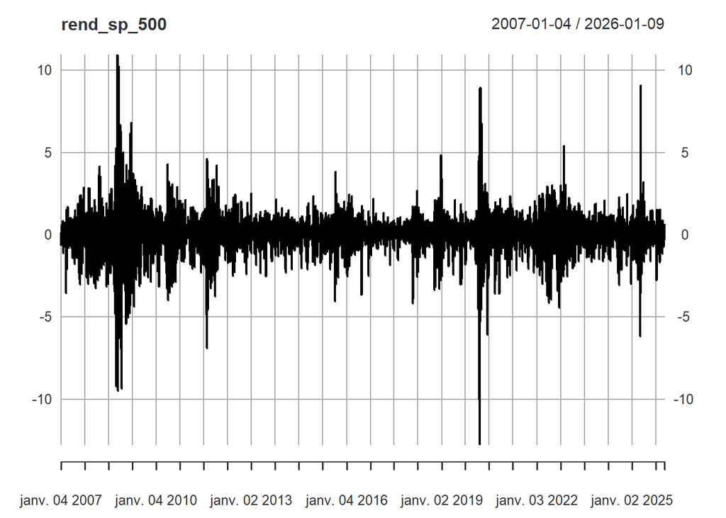

```r
# Représenter la série des rendements
rend_sp_500 |>
  plot()
```

On rappelle que ces rendements sont stationnaires, présentent de la forte autocorrélation et ne suivent pas une lois normale :

```r
# N'exécuter que si le package dobby est installé
if (rlang::is_installed("dobby")) {
  # Test ADF automatique
  dobby::adf_test_auto(
    rend_sp_500,
    "S&P500",
    lags = 20,
    return_res = FALSE
  )
}
```

```
#################################################
# Augmented Dickey-Fuller test for S&P500 serie #
#################################################
```

```
model selected : Without drift and trend
```

```
Lags number : 19
```

```
H0 : S&P500 serie has at least one unit root
```

```
t stat : -15.4004792278914
```

```
✔ H0 is rejected with for 5% confidence. S&P500 serie has no unit root.
```

```r
# Exécuter uniquement si le package dobby est installé
if (is_installed("dobby")){
  # Test de Ljung-Box
  dobby::check_univariate_autocorr(
    rend_sp_500, # Série à tester
    "S&P500", # Nom à donner à la série
    test_type = "Ljung-Box", # Nom du test d'auto-corrélation
    return_output = FALSE # Faut-il retourner un tableau de résultats
  )
}
```

```
#############################
# Ljung-Box test for S&P500 #
#############################
```

```
H0 : There is no autocorrelation in 'S&P500' for a given lag number
```

```
[[1]]

    Box-Ljung test

data:  serie
X-squared = 71.853, df = 1, p-value < 0.00000000000000022


[[2]]

    Box-Ljung test

data:  serie
X-squared = 170.47, df = 20, p-value < 0.00000000000000022
```

```r
# Excuter uniquement si le package dobby est installé
if (rlang::is_installed("dobby")) {
  # tester la présence de skewness et de surplus de kurtosis
  dobby::check_univariate_normality(
    as.numeric(rend_sp_500), # Série : doit être un vecteur numérique   et pas une série temporelle
    "S&P500", # Nom à donner à la série
    return_output = FALSE # Faut-il retourner un tableau de résultats   ?
  )
}
```

```
####################################
# Normality tests for S&P500 serie #
####################################
```

```
    D'Agostino skewness test

data:  serie
skew = -0.4741, z = -12.7543, p-value < 0.00000000000000022
alternative hypothesis: data have a skewness


    Anscombe-Glynn kurtosis test

data:  serie
kurt = 15.466, z = 30.801, p-value < 0.00000000000000022
alternative hypothesis: kurtosis is not equal to 3


    Jarque-Bera Normality Test

data:  serie
JB = 31162, p-value < 0.00000000000000022
alternative hypothesis: greater
```

Nous avions trouvé que la meilleure modélisation ARIMA pour modéliser l’espérance conditionnelle de nos rendements était un $ARMA(4,5)$. Nous allons donc garder cette modélisation pour l’espérance conditionnelle.

```r
arma_4_5 <-
  forecast::Arima(
    rend_sp_500, # Série à modéliser
    order = c(4, 0, 5), # Ordres p, d, d (AR, I, MA) à utiliser
    include.mean = TRUE # Inclure une constante ou pas
  )
```

## Test des effets ARCH

Une fois la modélisation de la moyenne conditionnelle trouvée, il faut tester la présence d’effet ARCH afin de voir si les rendements sont caractérisés par une volatilité non-constante et dont la valeur dépend de son passé.

On peut pour cela utiliser le test de Ljung-Box sur les résidus au carré du modèle ARMA (ou bien sur les rendements au carré)

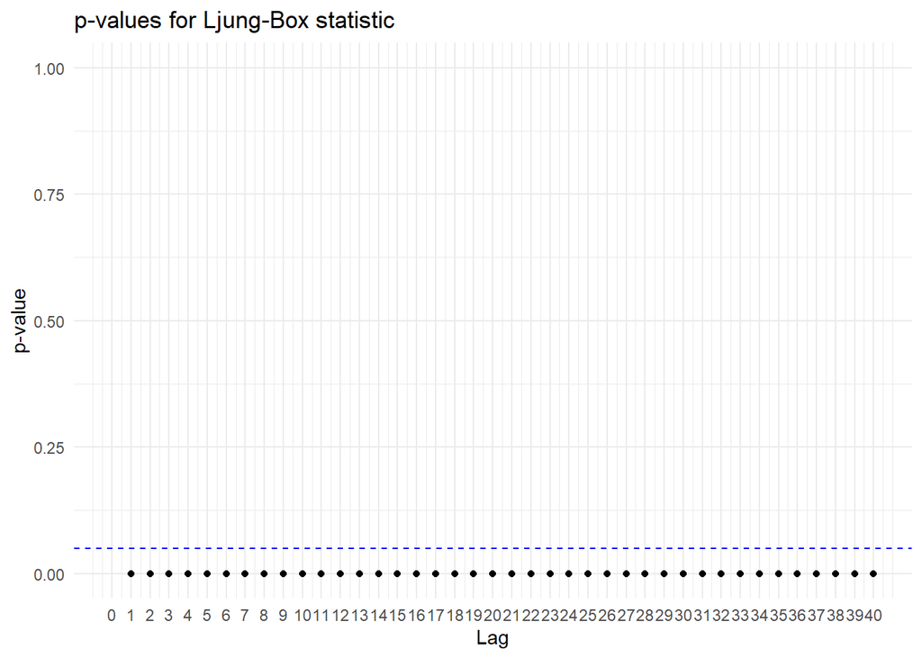

```r
# Calculer les résidus au carré du modèle ARMA
residus_2_arma_4_5 <- arma_4_5$residuals**2

# Tester la présence d'autocorrélation sur les résidus au carré
LSTS::Box.Ljung.Test(residus_2_arma_4_5, lag = 40)
```

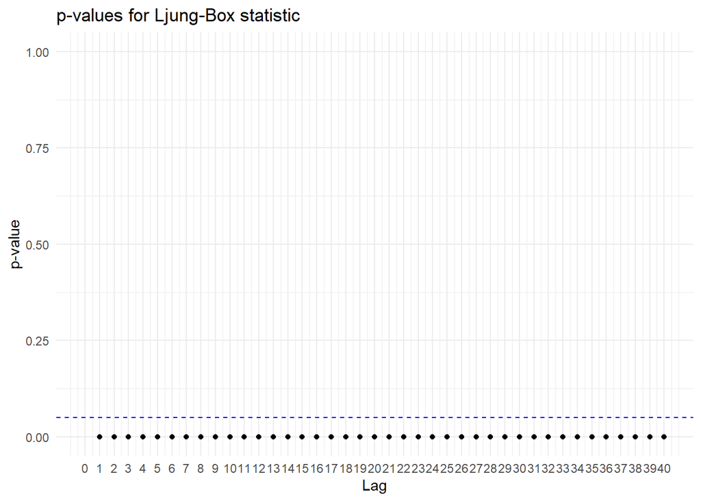

```r
# Tester l'autocorrélation sur les rendements au carré
LSTS::Box.Ljung.Test(rend_sp_500**2, lag = 40)
```

Le test de Ljung-Box indique que les rendements (résidus) au carré sont caractérisés par la présence d’une autocorrélation forte de leur volatilité. La volatilité des rendements dépend de ses valeurs passées.

```r
# ARCH test
fDMA::archtest(as.numeric(arma_4_5$residuals**2), lag = 20)
```

```
    Engle's LM ARCH Test

data:  as.numeric(arma_4_5$residuals^2)
statistic = 1057.6, lag = 20, p-value < 0.00000000000000022
alternative hypothesis: ARCH effects of order 20 are present
```

L’utilisation du test ARCH sur les résidus au carré indique également que les rendements semblent caractérisés par une volatilité conditionnelle non-constante. Une telle caractéristique est commune sur les marchés financiers et ne peut être prise en compte par une simple spécification ARMA qui modélise que l’espérance conditionnelle. Il faut adopter une spécification permettant de modéliser une volatilité conditionnelle non-constante.

## Estimation d’un modèle ARMA(4,5)-ARCH(1)

### Estimation du modèle

Pour essayer de prendre en compte cette volatilité conditionnelle non-constante, nous allons spécifier un modèle ARMA(4,5) pour modéliser l’espérance conditionnelle et un modèle ARCH(1) pour modéliser la volatilité conditionnelle des rendements.

Les modélisation (G)ARCH se font grâce au package `rugarch`. Contrairement aux modèles de régressions linéaires ou ARMA vu précédemment où la spécification et l’estimation s’effectuent au sein d’une seule fonction, le package `rugarch` sépare les deux étapes. Ainsi, on va spécifier l’équation de la moyenne conditionnelle et de la variance conditionnelle avec la fonction `rugarch::urgarchspec()`, puis on va estimer le modèle avec la fonction `rugarch::urgarchfit()`.

La fonction `rugarch::ugarchspec()` va prendre comme argument `variance.model` une liste contenant les spécifications de l’équation de la variance conditionnelle (type de modèle, régresseurs exogènes etc…) ; l’argument `mean.model` va servir à spécifier la modélisation de l’espérance conditionnelle ; l’argument `distribution.model` va servir à définir la distribution de probabilité que sont supposés suivre les résidus.

Ici nous allons estimé un modèle ARCH(1) pour la volatilité conditionnelle, un modèle ARMA(4,5) pour la moyenne conditionnelle et nous utiliser la loi normale pour la distribution des résidus.

```r
# Spécifier le modèle ARMA(4,5)-ARCH(1)
arch1_spec <-
  rugarch::ugarchspec(
    # Spécification de la variance conditionnelle
    variance.model =
      list(
        model = "sGARCH", # Utiliser un modèle GARCH
        garchOrder = c(1,0), # Ordres du GARCH(q,p) : p = 0 donc modèle ARCH
        variance.targeting = FALSE # Définir si on veut utiliser la variance non conditionnelle empirique comme cible ou non
      ),
    # Spécification de la moyenne conditionnelle
    mean.model =
      list(
        armaOrder = c(4,5), # Ordres (p,q) du modèle ARMA
        include.mean = TRUE # Inclure une constante
      ),
    distribution.model = "norm" # Distribution normale des résidus
  )
```

Une fois que l’on a spécifié le modèle, il faut l’estimer grâce à la fonction `rugarch::ugarchfit()` qui va prendre comme arguments la spécification ainsi que les données.

```r
# Estimer le modèle
arch1_fit <- rugarch::ugarchfit(
  arch1_spec, # Spécification du modèle
  rend_sp_500 # Données à utiliser
)

# Visualiser le résultat
arch1_fit
```

```
*---------------------------------*
*          GARCH Model Fit        *
*---------------------------------*

Conditional Variance Dynamics
-----------------------------------
GARCH Model : sGARCH(1,0)
Mean Model  : ARFIMA(4,0,5)
Distribution    : norm

Optimal Parameters
------------------------------------
        Estimate  Std. Error       t value Pr(>|t|)
mu      0.073211    0.006987       10.4782        0
ar1     0.192580    0.002365       81.4362        0
ar2    -0.017307    0.002810       -6.1596        0
ar3    -0.224315    0.000679     -330.4625        0
ar4     0.968646    0.001311      739.1157        0
ma1    -0.415262    0.000012   -33857.2647        0
ma2     0.070000    0.000312      224.0611        0
ma3     0.217662    0.002730       79.7391        0
ma4    -1.016691    0.000000 -9961478.2329        0
ma5     0.215662    0.002783       77.4810        0
omega   0.810087    0.024023       33.7219        0
alpha1  0.580058    0.035168       16.4938        0

Robust Standard Errors:
        Estimate  Std. Error       t value Pr(>|t|)
mu      0.073211    0.025841        2.8332 0.004609
ar1     0.192580    0.006173       31.1960 0.000000
ar2    -0.017307    0.005746       -3.0121 0.002594
ar3    -0.224315    0.005272      -42.5493 0.000000
ar4     0.968646    0.004357      222.3096 0.000000
ma1    -0.415262    0.000035   -11827.3124 0.000000
ma2     0.070000    0.000654      107.0663 0.000000
ma3     0.217662    0.007010       31.0520 0.000000
ma4    -1.016691    0.000000 -3982983.8960 0.000000
ma5     0.215662    0.006322       34.1152 0.000000
omega   0.810087    0.065844       12.3031 0.000000
alpha1  0.580058    0.082504        7.0307 0.000000
```

[output cut: 65 more lines]

```
Adjusted Pearson Goodness-of-Fit Test:
------------------------------------
  group statistic
1    20     519.7
2    30     555.9
3    40     595.5
4    50     614.1
                                                                                               p-value(g-1)
1 0.0000000000000000000000000000000000000000000000000000000000000000000000000000000000000000000000000412500
2 0.0000000000000000000000000000000000000000000000000000000000000000000000000000000000000000000000000087655
3 0.0000000000000000000000000000000000000000000000000000000000000000000000000000000000000000000000000001119
4 0.0000000000000000000000000000000000000000000000000000000000000000000000000000000000000000000000000109502


Elapsed time : 3.189273
```

Les résultats sont organisés de la façon suivante :

- **Conditional Variance Dynamics** : spécification du modèle
- **Optimal Parameters** : Paramètres de la moyenne et de la variance conditionnelle ainsi que leur erreur standard. les paramètres `mu`, `ar...` et `ma...` indique les paramètres de la modélisation ARMA de la moyenne conditionnelle. Le paramètre `omega` indique la constante dans l’équation de la variance conditionnelle. Il s’agit de la volatilité moyenne de la série. Le paramètre `alpha1` indique le paramètre ARCH.
- **Robust Standard Errors** : Paramètres et erreurs standards. Les erreurs standard sont corrigées pour tenir compte de l’autocorrélation et de l’hétéroscédasticité. La valeur des paramètres restent inchangés.
- **Information Criteria** : Critères d’information du modèle.
- **Weighted Ljung-Box Test on Standardized Residuals** : Test de Ljung-Box sur les résidus standardisés pour vérifier la présence ou non d’autocorrélation dans les rendements. Sert à vérifier si le modèle ARMA prend bien en compte toute l’autocorrélation.
- **Weighted Ljung-Box Test on Standardized Squared Residuals** : Test de Ljung-Box sur les résidus standardisés au carré. Sert à vérifier si le modèle type GARCH prend bien en compte toute l’autocorrélation de la volatilité conditionnelle.
- **Nyblom stability test** : Test de stabilité dans le temps des coefficients. Sert à vérifier qu’il n’y a pas de de break structurels.
- **Sign Bias Test** : Tester s’il existe dans l’asymétrie dans la réponse de la volatilité à un choc de rendements.

La première chose à vérifier sont les conditions de positivité du modèle. Il faut que les paramètres `Omega` et `alpha1` soient supérieurs ou égaux à 0 ce qui est le cas ici (0.81 et 0.58 respectivement). On vérifier ensuite que le paramètre ARCH est significatif (sinon aucun intérêt de le prendre en compte). La t-stat associée est de 16.49 et la p.value est de 0. On rejette donc l’hypothèse nulle. Le coefficient est bien significativement différent de 0, et ce même si l’on prend des erreurs standard robustes.

On peut voir que le test de Ljung-Box sur les résidus standardisés rejettent l’hypothèse nulle de non-autocorrélation. Il semblerait que le modèle ARMA(4,5) ne soit pas suffisant pour prendre en compte toute l’autocorrélation des rendements malgré l’analyse initiale. Dans ce cas, il serait rigoureux de changer de modèle pour la moyenne conditionnelle (ce que l’on ne va pas faire ici).

Le test de Ljung-Box sur les résidus standardisés au carré rejette l’hypothèse nulle. Tous les effets ARCH, surtout de long-terme n’ont pas été pris en compte. Il faudrait changer de type de modèle ARCH ou augmenter les ordres. La conclusion du test ARCH est similaire.

Les test de biais indiquent pour deux d’entre eux qu’il semble exister une asymétrie dans la réponse de la volatilité conditionnelle à un choc sur elle même ou sur les rendements. Il faudrait donc changer de modèle pour utiliser une spécification qui permet de prendre en compte ces effets asymétriques.

On sait également que nos rendements ne suivent pas une loi normale. Ils sont caractérisés par une kurtosis plus élevée et une asymétrie négative. Il serait donc opportun de changer la distribution que sont supposés suivre les résidus. Les différentes possibilités implémentées par le package `rugarch` sont :

- **norm** : pour une distribution normale
- **snorm** : pour une distribution normale asymétrique
- **std** : pour une distribution de Student
- **sstd** : pour une distribution asymétrique de Student
- **ged** : pour une distribution généralisée des erreurs (kurtosis plus élevée et distribution plus flexible)
- **sged** : pour une distribution généralisée des erreurs asymétrique
- **nig** : pour une distribution normale inverse (normal inverse gaussian distribution)
- **ghyp** : pour une distribution généralisée hyperbolique
- **jsu** : pour une distribution Su de Johnson

Nous allons rester relativement simple et utiliser une distribution de Student asymétrique pour prendre en compte des queues de distribution plus épaisse et l’asymétrie de nos rendements.

### Divers résultats

On peut calculer la persistance du modèle (la somme des coefficients GARCH) grâce à la fonction `rugarch::persistence()`.

```r
# Calculer la persistance du modèle
rugarch::persistence(arch1_fit)
```

```
[1] 0.5800584
```

Le résultat est bien égal au coefficient `alpha1` puisqu’il s’agit du seul paramètre GARCH.

On peut également calculer la demi-vie, c’est à dire le temps qu’il faut pour que la moitié d’un choc soit absorbée (revienne vers sa moyenne) avec la fonction `rugarch::halflife()`

```r
# Calculer la demi-vie
rugarch::halflife(arch1_fit)
```

```
[1] 1.272702
```

La persistance de ce modèle étant faible, un choc met 1,27 jours pour être à moitié absorbé.

On peut calcuelr la variance non-conditionnelle estimée par le modèle et la comparer avec la vraie variance non-conditionnelle de nos rendements

```r
# Volatilité non conditionnelle des rendements
sd(as.numeric(rend_sp_500))
```

```
[1] 1.253027
```

```r
# Volatilité non conditionnelle estimée du modèle
sqrt(uncvariance(arch1_fit))#volatilité non conditionnelle estimée de notre modèle
```

```
[1] 1.388901
```

En utilisant la fonction `plot()` on peut obtenir un certain nombre de graphiques de diagnostique pour notre modèle.

```r
plot(arch1_fit, which = "all")
```

On peut y retrouver des graphiques de la VaR à 1%, de la volatilité conditionnelle, de la loi suivie par les résidus, des graphiques d’autocorrélation etc… En changeant la valeur du paramètre `which` par un chiffre, on peut choisir de ne visualiser qu’un seul graphique.

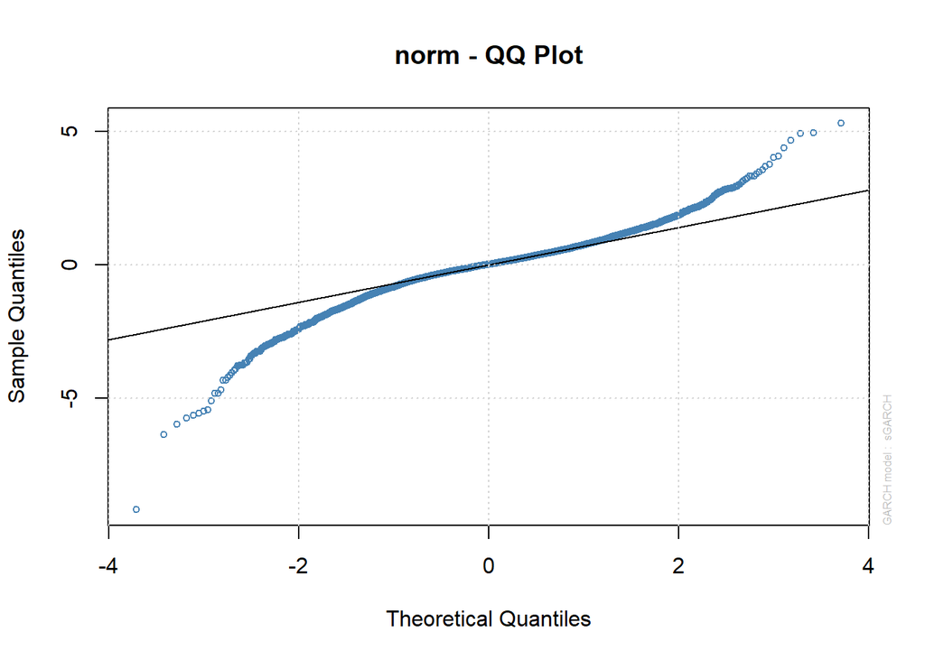

```r
plot(arch1_fit, which = 9)
```

On peut voir sur ce graphique que les quantiles empiriques de nos résidus standardisés s’éloignent fortement des quantiles théoriques de la loi normale. Cela est attendue puisque l’on sait que nos résidus ne suivent pas une loi normale.

La fonction `rugarch::sigma()` permet d’obtenir l’estimation de la variance conditionnelle du modèle et donc de la volatilité conditionnelle de nos rendements.

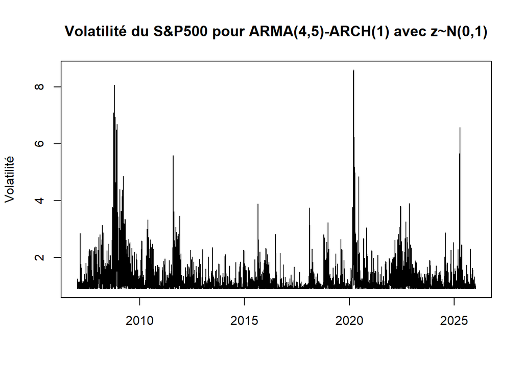

```r
# Obtenir la volatilityé conditionnelle estimée des rendements
rugarch::sigma(arch1_fit) |>
  # Transformer en objet de séries temporelles
  as.zoo() |>
  # Représenter graphiquement
  plot(
    main="Volatilité du S&P500 pour ARMA(4,5)-ARCH(1) avec z~N(0,1)",
     xlab = "",
     ylab = "Volatilité"
  )
```

Comme attendu, la volatilité estimée est bien plus forte en période de crise. Cette volatilité semble bien autocorrélée en cluster de volatilité.

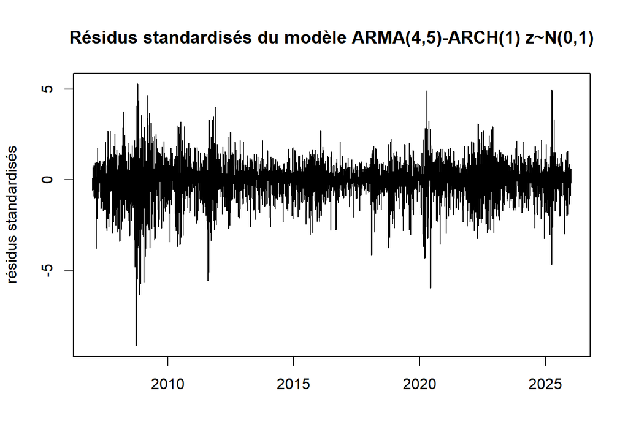

```r
rugarch::residuals(arch1_fit, standardize = TRUE) |>
  as.zoo() |>
  plot(
    main = "Résidus standardisés du modèle ARMA(4,5)-ARCH(1) z~N(0,1)",
     xlab = "",
     ylab = "résidus standardisés"
  )
```

Il semble que l’on ait toujours graphiquement des cluster de volatilité, ce qui est confirmé par les tests de Ljung-Box et ARCH. Notre modèle ne permet pas de prendre en compte toute l’autocorrélation de la volatilité.

## Estimation d’un modèle ARMA(4,5)-GARCH(1,1) sstd

On va dans un premier temps passer à une spécification GARCH(1,1) afin de prendre en compte d’avantage d’autocorrélation de la volatilité. On va également utiliser un ciblage de variance pour forcer la variance non-conditionnelle estimer à être égale à celle observée dans les rendements (le but est de coller au plus près des rendements). On va également utiliser une distribution de Student asymétrique afin de prendre en compte des queues de distribution plus épaisses et une possible asymétrie dans nos rendements.

```r
# Spécifier le modèle ARMA(4,5)-ARCH(1)
garch11_spec <-
  rugarch::ugarchspec(
    # Spécification de la variance conditionnelle
    variance.model =
      list(
        model = "sGARCH", # Utiliser un modèle GARCH
        garchOrder = c(1,1), # Ordres du GARCH(q,p)
        variance.targeting = TRUE # Définir si on veut utiliser la variance non conditionnelle empirique comme cible ou non
      ),
    # Spécification de la moyenne conditionnelle
    mean.model =
      list(
        armaOrder = c(4,5), # Ordres (p,q) du modèle ARMA
        include.mean = TRUE # Inclure une constante
      ),
    distribution.model = "sstd" # Distribution de Student asymétrique des résidus
  )
```

Une fois que l’on a spécifié le modèle, il faut l’estimer grâce à la fonction `rugarch::ugarchfit()` qui va prendre comme arguments la spécification ainsi que les données.

```r
# Estimer le modèle
garch11_fit <- rugarch::ugarchfit(
  garch11_spec, # Spécification du modèle
  rend_sp_500 # Données à utiliser
)

# Visualiser le résultat
garch11_fit
```

```
*---------------------------------*
*          GARCH Model Fit        *
*---------------------------------*

Conditional Variance Dynamics
-----------------------------------
GARCH Model : sGARCH(1,1)
Mean Model  : ARFIMA(4,0,5)
Distribution    : sstd

Optimal Parameters
------------------------------------
        Estimate  Std. Error    t value Pr(>|t|)
mu      0.072850    0.007292     9.9911 0.000000
ar1    -0.885950    0.012778   -69.3330 0.000000
ar2     0.742947    0.020163    36.8472 0.000000
ar3     0.538998    0.020406    26.4140 0.000000
ar4    -0.197107    0.030135    -6.5408 0.000000
ma1     0.796311    0.000297  2679.9985 0.000000
ma2    -0.869759    0.019088   -45.5665 0.000000
ma3    -0.557701    0.000358 -1559.6167 0.000000
ma4     0.191552    0.031300     6.1199 0.000000
ma5    -0.027965    0.012372    -2.2604 0.023796
alpha1  0.125417    0.001209   103.7193 0.000000
beta1   0.863811    0.000772  1119.2203 0.000000
skew    0.820032    0.018499    44.3285 0.000000
shape   6.234890    0.474799    13.1316 0.000000
omega   0.016802          NA         NA       NA

Robust Standard Errors:
        Estimate  Std. Error   t value Pr(>|t|)
mu      0.072850    0.007969    9.1419 0.000000
ar1    -0.885950    0.011390  -77.7834 0.000000
ar2     0.742947    0.013805   53.8166 0.000000
ar3     0.538998    0.020768   25.9530 0.000000
ar4    -0.197107    0.030493   -6.4641 0.000000
ma1     0.796311    0.000334 2387.6686 0.000000
ma2    -0.869759    0.009865  -88.1680 0.000000
ma3    -0.557701    0.000639 -873.3805 0.000000
ma4     0.191552    0.031435    6.0936 0.000000
```

[output cut: 68 more lines]

```
Negative Sign Bias   1.544 0.122746077081
Positive Sign Bias   1.849 0.064524356090   *
Joint Effect        44.074 0.000000001456 ***


Adjusted Pearson Goodness-of-Fit Test:
------------------------------------
  group statistic p-value(g-1)
1    20     64.22 0.0000008182
2    30     78.97 0.0000016383
3    40     94.86 0.0000014857
4    50    102.07 0.0000133655


Elapsed time : 1.483046
```

On peut voir que de nouveaux coefficients sont apparus. Le paramètre `beta1` est le paramètre généralisé du modèle GARCH. Le paramètre `skew` représente le coefficient d’asymétrie de la distribution sstd estimée. Le paramètre `shape` correspond au paramètre de la loi sstd estimée. On peut voir que le paramètre `Omega` qui est la constante présente dans l’équation de la variance conditionnelle n’a plus d’erreur standard. Cela est du à l’utilisation de `variance.targeting = TRUE` qui va imposer une valeur sur cette constante qui va dépendre de la persistance du modèle et de la variance inconditionnelle des rendements. Ce n’est donc pas une estimation.

On peut vérifier que la variance non-conditionnelle estimée est très proche de la vraie variance non-conditionnelle :

```r
# Volatilité non conditionnelle des rendements
sd(as.numeric(rend_sp_500))
```

```
[1] 1.253027
```

```r
# Volatilité non conditionnelle estimée du modèle
sqrt(uncvariance(garch11_fit))
```

```
[1] 1.248888
```

On vérifier les contraintes de positivités. Les coefficients `omega`, `alpha1` et `beta1` sont supérieurs à 0. Ces coefficients sont significativement différent de 0 et la somme de `alpha1` et `beta1` est inférieure à 1 donc le modèle est stationnaire :

```r
# Persistence du modèle : alpha1 + beta1
rugarch::persistence(garch11_fit)
```

```
[1] 0.9892277
```

La persistance du modèle est bien plus élevée que pour le modèle ARCH puisque l’on rajoute une dépendance à la variance conditionnelle passée dans l’équation de la variance conditionnelle.

```r
# Calculer la demi-vie
rugarch::halflife(garch11_fit)
```

```
[1] 63.99796
```

On peut voir que la demi-vie est bien plus élevée. IL faut désormais 64 jours pour qu’un choc soit à moitié absorbée et commence à revenir vers sa moyenne.

On peut voir également, que l’on prend légèrement plus en compte l’autocorrélation des résidus à l’ordre 1 mais quelle existe toujours surtout dans les ordres supérieurs. En revanche passer à un modèle GARCH semble avoir supprimé l’autocorrélation des rendements au carré. Il semblerait que ce modèle permet de bien prendre en compte tous les effets ARCH de nos rendements.

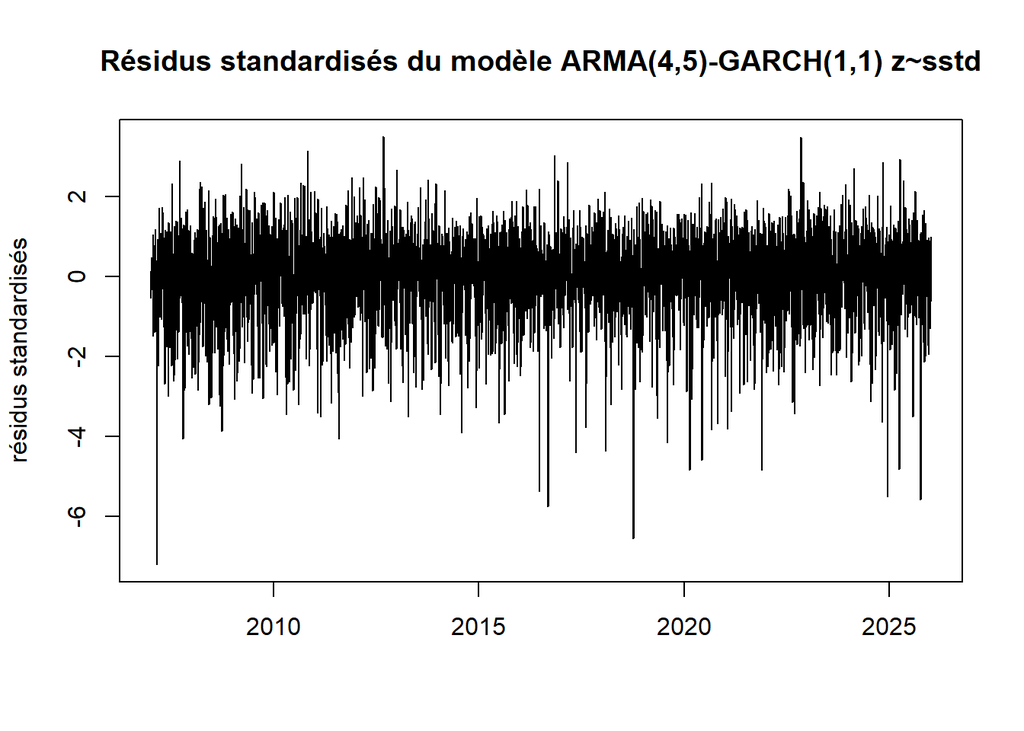

```r
# Représenter les résidus standardisés
rugarch::residuals(garch11_fit, standardize = TRUE) |>
  as.zoo() |>
  plot(
    main = "Résidus standardisés du modèle ARMA(4,5)-GARCH(1,1) z~sstd",
     xlab = "",
     ylab = "résidus standardisés"
  )
```

On voit bien de manière graphique qu’il ne semble plus y avoir réellement de cluster de volatilité au sein de nos résidus standardisés.

De manière attendue, on retrouve toujours des signes d’asymétrie dans la réponse de la volatilité puisque ce modèle ne permet pas de prendre en compte ce genre d’effets.

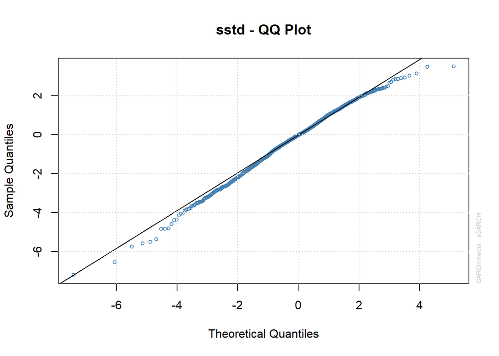

```r
plot(garch11_fit, which = 9)
```

On peut voir graphiquement, que les quantiles empiriques de nos résidus standardisés s’éloignent bien moins des quantiles théoriques de la loi sstd qu’ils ne s’éloignaient des quantiles théoriques de la loi normale. Cela semble indiquer que l’on prend mieux en compte la kurtosis et la skewness de nos rendements. Mais on peut voir que ce résultat n’est pas parfait.

La fonction `rugarch::sigma()` permet de récupérer la volatilité conditionnelle estimée du modèle.

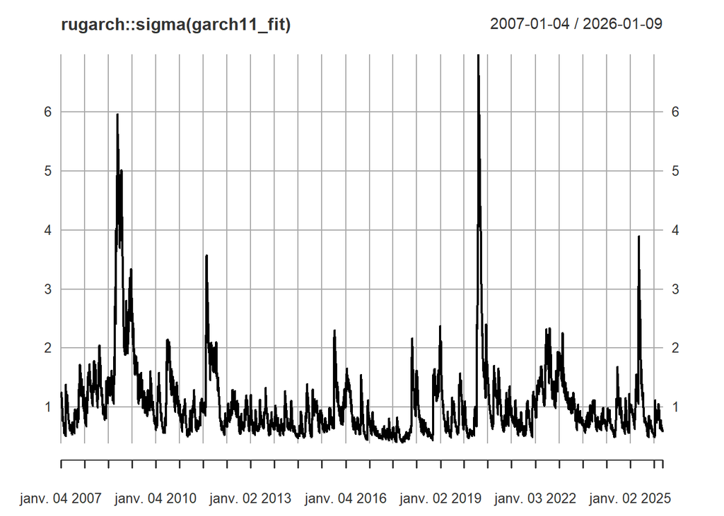

```r
# Réprésenter la volatiloté estimée du modèle
garch11_fit |>
  rugarch::sigma() |>
  plot()
```

Comme on s’y attendais, on observe des pics de volatilité lors des périodes de crises ou d’incertitudes. On observe également qu’effectivement la volatilité est organisée en cluster de volatilité. Une forte (faible) volatilité semble entrainer par la suite une forte (faible) volatilité.

## Estimation d’un modèle ARMA(4,5)-GJR-GARCH(1,1)

On, va maintenant estimer un modèle GJR-GARCH afin d’essayer de prendre en compte les effets d’asymétrie que l’on a pu remarquer dans nos spécification précédentes. Pour cela on va indiquer `model = "gjrGARCH`.

```r
# Spécifier le modèle ARMA(4,5)-GJR-ARCH(1)
gjr_garch11_spec <-
  rugarch::ugarchspec(
    # Spécification de la variance conditionnelle
    variance.model =
      list(
        model = "gjrGARCH", # Utiliser un modèle GJR-GARCH
        garchOrder = c(1,1), # Ordres du GARCH(q,p)
        variance.targeting = TRUE # Définir si on veut utiliser la variance non conditionnelle empirique comme cible ou non
      ),
    # Spécification de la moyenne conditionnelle
    mean.model =
      list(
        armaOrder = c(4,5), # Ordres (p,q) du modèle ARMA
        include.mean = TRUE # Inclure une constante
      ),
    distribution.model = "sstd" # Distribution de Student asymétrique des résidus
  )
```

Une fois que l’on a spécifié le modèle, il faut l’estimer grâce à la fonction `rugarch::ugarchfit()` qui va prendre comme arguments la spécification ainsi que les données.

```r
# Estimer le modèle
gjr_garch11_fit <- rugarch::ugarchfit(
  gjr_garch11_spec, # Spécification du modèle
  rend_sp_500 # Données à utiliser
)

# Visualiser le résultat
gjr_garch11_fit
```

```
*---------------------------------*
*          GARCH Model Fit        *
*---------------------------------*

Conditional Variance Dynamics
-----------------------------------
GARCH Model : gjrGARCH(1,1)
Mean Model  : ARFIMA(4,0,5)
Distribution    : sstd

Optimal Parameters
------------------------------------
        Estimate  Std. Error       t value Pr(>|t|)
mu      0.035404    0.009114      3.884598 0.000102
ar1    -0.374629    0.000368  -1019.085728 0.000000
ar2     1.171199    0.000249   4703.230355 0.000000
ar3    -0.203822    0.000330   -617.226117 0.000000
ar4    -0.911283    0.000234  -3899.507060 0.000000
ma1     0.309223    0.000050   6211.035390 0.000000
ma2    -1.207102    0.000105 -11507.889523 0.000000
ma3     0.260622    0.000084   3094.800136 0.000000
ma4     0.889439    0.000007 126567.580055 0.000000
ma5    -0.058775    0.000011  -5273.877536 0.000000
alpha1  0.000000    0.000306      0.000627 0.999500
beta1   0.863109    0.000014  61815.853879 0.000000
gamma1  0.262387    0.003627     72.348491 0.000000
skew    0.830234    0.017916     46.341649 0.000000
shape   5.747117    0.438295     13.112429 0.000000
omega   0.023441          NA            NA       NA

Robust Standard Errors:
        Estimate  Std. Error       t value Pr(>|t|)
mu      0.035404    0.008725      4.057646  0.00005
ar1    -0.374629    0.000197  -1905.347111  0.00000
ar2     1.171199    0.000155   7536.467029  0.00000
ar3    -0.203822    0.000312   -652.888545  0.00000
ar4    -0.911283    0.000115  -7907.533636  0.00000
ma1     0.309223    0.000072   4322.125302  0.00000
ma2    -1.207102    0.000049 -24618.914655  0.00000
ma3     0.260622    0.000052   5002.564367  0.00000
```

[output cut: 71 more lines]

```
Negative Sign Bias  3.5154 0.000443126 ***
Positive Sign Bias  0.9422 0.346154980
Joint Effect       26.7077 0.000006779 ***


Adjusted Pearson Goodness-of-Fit Test:
------------------------------------
  group statistic p-value(g-1)
1    20     48.59    0.0002105
2    30     56.94    0.0014618
3    40     71.18    0.0012476
4    50     78.38    0.0048470


Elapsed time : 2.136403
```

Le coefficient `gamma1` représente le coefficient d’asymétrie du modèle. On sait que la variable associée au coefficient `gamma1` est une variable binaire qui va prendre la valeur 1 lorsque le choc de volatilité est négatif. Ainsi la réponse de la volatilité conditionnelle lorsque le choc de volatilité est positif est donné par le coefficient `alpha1`. La réponse de la volatilité conditionnelle lorsque le choc de volatilité est négatif est donné par la somme `alpha1 + gamma1`. Ici on peut voir que `alpha1` n’est pas statistiquement différent de 0. Cela indique que selon cette spécification la volatilité conditionnelle ne réagit pas à un choc de volatilité positif positif. Elle réagit simplement à un choc de volatilité négatif à hauteur de $0.26$.

## Estimation d’un modèle ARMA(4,5)-EGARCH(1,1) sstd

Pour essayer de mieux prendre en compte l’asymétrie, on va estimer un modèle EGARCH(1,1).

```r
# Spécifier le modèle ARMA(4,5)-EGARCH(1)
egarch11_spec <-
  rugarch::ugarchspec(
    # Spécification de la variance conditionnelle
    variance.model =
      list(
        model = "eGARCH", # Utiliser un modèle GJR-GARCH
        garchOrder = c(1,1), # Ordres du GARCH(q,p)
        variance.targeting = TRUE # Définir si on veut utiliser la variance non conditionnelle empirique comme cible ou non
      ),
    # Spécification de la moyenne conditionnelle
    mean.model =
      list(
        armaOrder = c(4,5), # Ordres (p,q) du modèle ARMA
        include.mean = TRUE # Inclure une constante
      ),
    distribution.model = "sstd" # Distribution de Student asymétrique des résidus
  )
```

Une fois que l’on a spécifié le modèle, il faut l’estimer grâce à la fonction `rugarch::ugarchfit()` qui va prendre comme arguments la spécification ainsi que les données.

```r
# Estimer le modèle
egarch11_fit <- rugarch::ugarchfit(
  egarch11_spec, # Spécification du modèle
  rend_sp_500 # Données à utiliser
)

# Visualiser le résultat
egarch11_fit
```

```
*---------------------------------*
*          GARCH Model Fit        *
*---------------------------------*

Conditional Variance Dynamics
-----------------------------------
GARCH Model : eGARCH(1,1)
Mean Model  : ARFIMA(4,0,5)
Distribution    : sstd

Optimal Parameters
------------------------------------
        Estimate  Std. Error      t value Pr(>|t|)
mu      0.009768    0.006999       1.3955  0.16286
ar1     0.048142    0.008894       5.4127  0.00000
ar2     0.987468    0.006321     156.2301  0.00000
ar3    -0.543423    0.007167     -75.8195  0.00000
ar4    -0.507265    0.008112     -62.5292  0.00000
ma1    -0.116107    0.000222    -522.7296  0.00000
ma2    -1.002322    0.000005 -213837.9826  0.00000
ma3     0.602063    0.000021   29238.6996  0.00000
ma4     0.472451    0.000102    4636.4913  0.00000
ma5    -0.037048    0.000613     -60.4594  0.00000
alpha1 -0.176824    0.008771     -20.1593  0.00000
beta1   0.974829    0.000878    1110.3642  0.00000
gamma1  0.178980    0.009631      18.5828  0.00000
skew    0.797460    0.016973      46.9836  0.00000
shape   5.623175    0.511436      10.9949  0.00000
omega   0.011017          NA           NA       NA

Robust Standard Errors:
        Estimate  Std. Error      t value Pr(>|t|)
mu      0.009768    0.007533       1.2967  0.19473
ar1     0.048142    0.006257       7.6945  0.00000
ar2     0.987468    0.004954     199.3177  0.00000
ar3    -0.543423    0.005530     -98.2687  0.00000
ar4    -0.507265    0.005509     -92.0808  0.00000
ma1    -0.116107    0.000214    -543.0016  0.00000
ma2    -1.002322    0.000006 -169169.0652  0.00000
ma3     0.602063    0.000025   24051.8285  0.00000
```

[output cut: 71 more lines]

```
Negative Sign Bias  2.7026 0.0069033 ***
Positive Sign Bias  0.8111 0.4173527
Joint Effect       18.4621 0.0003531 ***


Adjusted Pearson Goodness-of-Fit Test:
------------------------------------
  group statistic p-value(g-1)
1    20     50.63   0.00010573
2    30     68.61   0.00004685
3    40     69.43   0.00193464
4    50     94.51   0.00010232


Elapsed time : 1.416627
```

Dans le modèle EGARCH, il faut interpréter le paramètre `alpha1` comme l’effet de signe. Ici `alpha1` est significativement différent de 0 et est négatif (il n’y a pas de contraintes de positivité dans la spécification EGARCH). Cela signifie qu’un choc négatif de rendements va faire augmenter la volatilité conditionnelle tandis qu’un choc positif de rendements va faire diminuer la volatilité conditionnelle. Ce qui est bien l’effet de levier attendu. Le paramètre `gamma1` représente l’effet de taille. Plus le choc de rendement est éloigné de la moyenne attendue, plus l’effet sur la volatilité sera important.

Tout comme pour le modèle GJR-GARCH, toute l’autocorrélation des rendements et rendements au carré semble avoir été prise en compte, mais on n’a pas réussi à prendre en compte tous les effets de signe. Pour être rigoureux, il faudrait probablement estimer un autre type de modélisation ou bien augmenter les ordres.

## Sélection du modèle

Les modèles ARCH(1) et GARCH(1,1) ne sont pas retenus pour modéliser la volatilité conditionnelle des rendements puisque l’on n’arrive à modéliser toute l’autocorrélation ainsi que les effets de signes. Les modèles GJR-GARCH et EGARCH font mieux sur tous les points mais ne sont pas parfait sur les effets de signe. On hésite donc entre ces deux modèles asymétriques. Pour les comparer on peut regarder leurs critères d’information. On peut obtenir les critères d’information de nos modèles avec la fonction `rugarch::infocriteria()`.

```r
# Créer une tible contenant les critères d'information de chaque modèle
table_criterion <-
  tibble(
    criterion = row.names(rugarch::infocriteria(arch1_fit)),
    ARCH_1 = as.numeric(rugarch::infocriteria(arch1_fit)),
    GARCH_11 = as.numeric(rugarch::infocriteria(garch11_fit)),
    GJR_GARCH_11 = as.numeric(rugarch::infocriteria(gjr_garch11_fit)),
    EGARCH_11 = as.numeric(rugarch::infocriteria(egarch11_fit))
  ) |>
  print()
```

```
# A tibble: 4 × 5
  criterion    ARCH_1 GARCH_11 GJR_GARCH_11 EGARCH_11
  <chr>         <dbl>    <dbl>        <dbl>     <dbl>
1 Akaike         3.07     2.66         2.62      2.62
2 Bayes          3.08     2.67         2.64      2.64
3 Shibata        3.07     2.66         2.62      2.62
4 Hannan-Quinn   3.07     2.66         2.63      2.63
```

```r
# Obtenir le modèle qui minimise chaque critère d'information
table_criterion |>
  # Pivoter la table pour obtenir tous les modèles dans une seule colonne
  pivot_longer(
    cols = !criterion,
    names_to = "model",
    values_to = "value"
  ) |>
  # Trouver la ligne de la colonne value qui minimise chaque critère d'information
  slice_min(
    by = criterion,
    value
  )
```

```
# A tibble: 4 × 3
  criterion    model     value
  <chr>        <chr>     <dbl>
1 Akaike       EGARCH_11  2.62
2 Bayes        EGARCH_11  2.64
3 Shibata      EGARCH_11  2.62
4 Hannan-Quinn EGARCH_11  2.63
```

Les 4 critères d’information indiquent que le modèle EGARCH(1,1) est celui qui reproduit le mieux les données sous contrainte de parcimonie. On utilisera donc principalement ce modèle pour le calcul de la Value at Risk.

## Value at Risk non conditionnelle

### Value at Risk non-conditionnelle historique

On va commencer par calculer la Value at Risk non conditionnelle (ne dépend pas d’un ensemble d’information) historique (uniquement à partir des données. On ne suppose pas une loi suivie par les rendements). Pour cela il suffit de calculer le quantile voulu de la distribution empirique de nos rendements :

```r
# Calcul de la VaR non conditionnelle historique pour un taux de couverture à 1%
VaR_historique <- -quantile(as.numeric(rend_sp_500), probs = 0.01) |>  print()
```

```
     1%
3.63455
```

La VaR non conditionnelle historique est de 3.64%. Cela signifie qu’il y aurait 1% de chance d’observer une perte supérieure à 3.64%. On peut représenter graphiquement ce que cela représente :

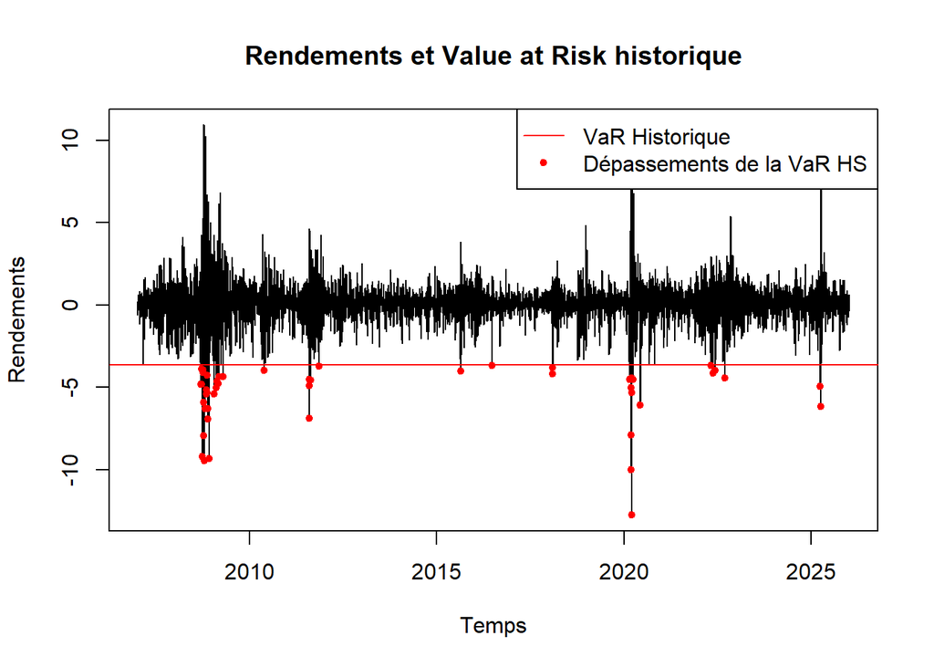

```r
# Représenter les rendements et les dépassements de la VaR selon une loi normale
# Représenter les rendements du S&P500
plot(
  as.zoo(rend_sp_500),
  main = "Rendements et Value at Risk historique",
  xlab = "Temps",
  ylab = "Rendements"
)
# Ajouter une ligne pour la VaR historique
abline(h=-VaR_historique, col="red")
# Ajouter des points sur les dépassements de la VaR
points(as.zoo(rend_sp_500[as.numeric(rend_sp_500) < -VaR_historique]), pch=20, col="red")
legend("topright", legend = c("VaR Historique","Dépassements de la VaR HS"),
       pch = c(NA,20), lty = c(1, NA), col = "red")
```

### Value at Risk non conditionnelle selon une loi normale

On peut également calculer la value at risk en supposant que les rendements suivent une loi normale. Au lieu de calculer le quantile empirique, on trouve le quantile de la loi normale avec la fonction `qnorm()` que l’on multiplie par l’écart-type empirique et auquel on ajoute la moyenne empirique (Car si on suppose que les rendements suivent une loi normale, cela ne veut pas dire que l’on suppose qu’ils suivent une loi normale centrée réduite).

```r
# Calcul de la VaR non conditionnelle selon une loi normale
VaR_VCov<- -(mean(rend_sp_500)+sd(rend_sp_500)*qnorm(0.01)) |>  print()
```

```
[1] 2.881689
```

La VaR en calculée en supposant que les rendements suivent une loi normale est plus faible que la VaR historique. Cela est attendue puisque l’on sait que les valeurs extrêmes sont plus fréquentes dans les rendements par rapport à la loi normale. Selon cette VaR il y aurait 1% de chance d’obtenir une perte supérieure à 2.88%.

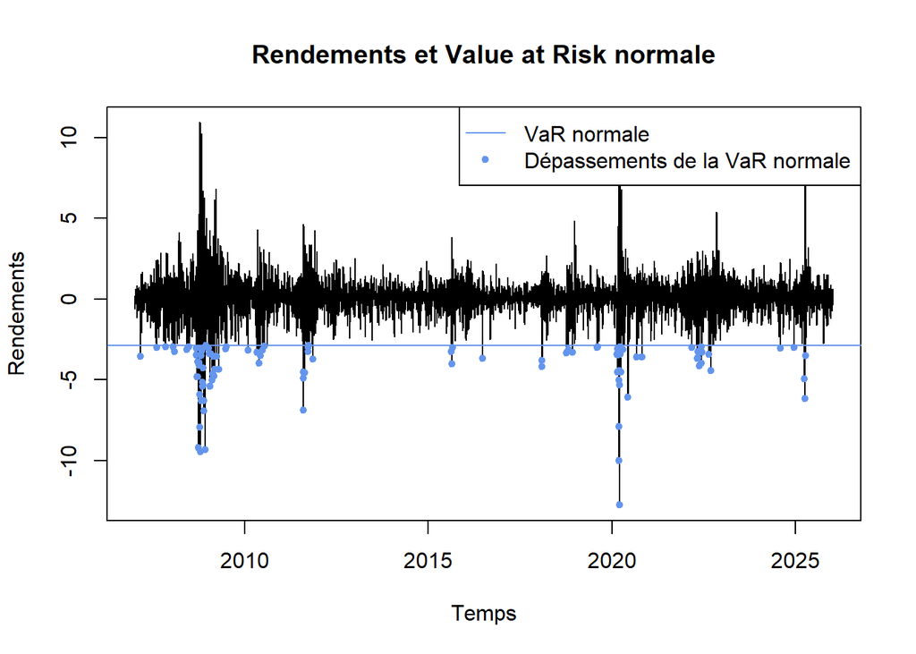

```r
# Représenter les rendements et les dépassements de la VaR selon une loi normale
# Représenter les rendements du S&P500
plot(
  as.zoo(rend_sp_500),
  main = "Rendements et Value at Risk normale",
  xlab = "Temps",
  ylab = "Rendements"
)
# Ajouter une ligne pour la VaR normale
abline(h=-VaR_VCov, col="cornflowerblue")
# Ajouter des points sur les dépassements de la VaR
points(as.zoo(rend_sp_500[as.numeric(rend_sp_500) < -VaR_VCov]), pch=20, col="cornflowerblue")
legend("topright", legend = c("VaR normale","Dépassements de la VaR normale"),
       pch = c(NA,20), lty = c(1, NA), col = "cornflowerblue")
```

Evidemment les dépassements sont plus nombreux que pour la VaR historique vu que la valeur est plus faible.

## Value at Risk non conditionnelle (fenêtre glissante)

Ces mesures de la VaR ne sont guère utiles si l’on estime que la volatilité n’est pas constante dans le temps. Pour palier ce problème, on peut estimer les VaR non conditionnelle à partir d’une fenêtre glissante. L’idée est de calculer la VaR sur un sous échantillon de $t$ jours puis de décaler cet échantillon d’un jour, de calculer la VaR dessus etc… On aura aisni une mesure de la VaR qui varie dans le temps. Evidemment les résultats sont très sensibles à la taille de l’échantillon.

Pour utiliser une fenêtre glissante on peu utiliser la fonction `zoo::rollapply()` ou `runner::runner()`. Ici on utilisera la première option. On utilisera une taille de fenêtre de 252 jours.

### Value at Risk non-conditionnelle historique

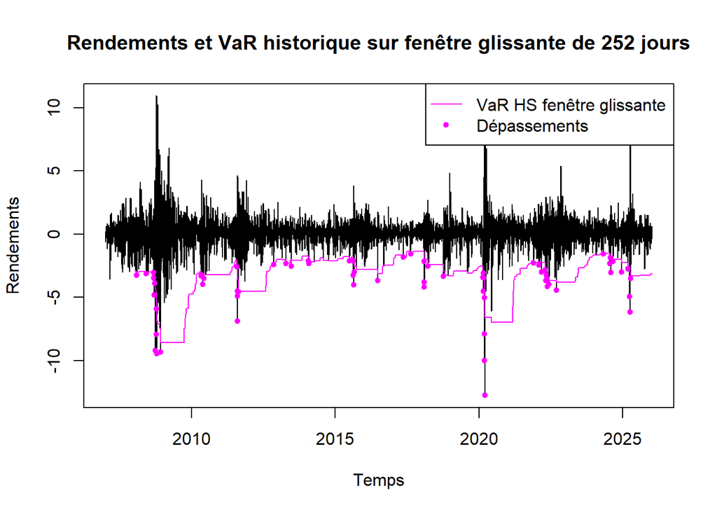

```r
#Calcul de la VaR historique sur fenêtre glissante de 252 jours
VaR_rolling_historique <-
  -zoo::rollapply(
    rend_sp_500, # Données à utiliser
    width=252, # Taille de la fenêtre
    FUN = quantile, # Fonction à utiliser : ici la fonction quantile
    probs=0.01 # Probabilité de la VaR / argument à passer à la fonction quantile
  )

# Représenter graphiquement la VaR hsitorique et ses dépassements
plot(as.zoo(rend_sp_500),
     main = "Rendements et VaR historique sur fenêtre glissante de 252 jours",
     xlab = "Temps",
     ylab = "Rendements")
lines(as.zoo(-VaR_rolling_historique), col = "magenta")
points(as.zoo(rend_sp_500[as.numeric(rend_sp_500) < -VaR_rolling_historique]), pch=20, col="magenta")
legend("topright", legend = c("VaR HS fenêtre glissante", "Dépassements"),
       lty = c(1,NA), pch = c(NA,20) ,col = "magenta")
```

On peut voir que la VaR réagit aux conditions économiques mais peut être assez lente à diminuer lorsque la volatilité décroit. Cela est du à la taille de la fenêtre qui garde l’information des 252 derniers jours. Une fenêtre plus petite montrerait certainement un ajustement plus rapide.

### Value at Risk non conditionnelle normale (fenêtre glissante)

On peut calculer la VaR en fenêtre glissante en supposant que les rendements suivent une loi normale.

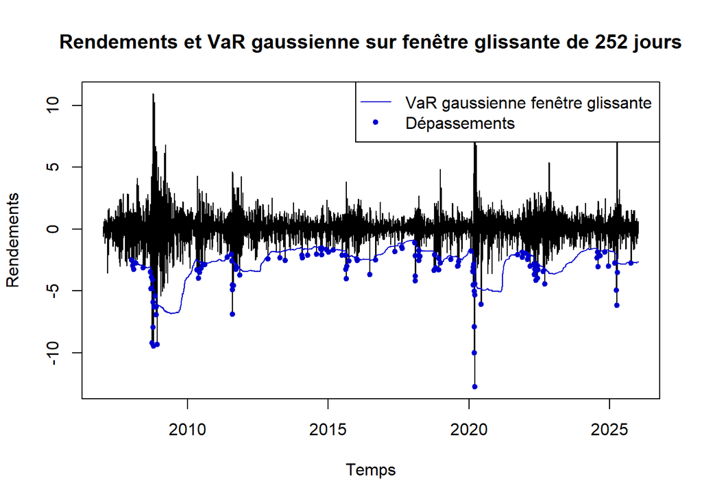

```r
# Calculer  la VaR normale non conditionnelle sous fenêtre glissante

# Calcuelr l'écart type en fenêtre glissante
rolling_sd <- zoo::rollapply(rend_sp_500,width=252,FUN = sd)

# Calculer la moyenne en fenêtre glissante
rolling_mean <- zoo::rollapply(rend_sp_500,width=252,FUN = mean)

# Pour chaque valeur de la moyenne et de l'écart-type calculer la VaR grâce au quantile de la loi normale
VaR_rolling_normale <- -(rolling_mean+rolling_sd*qnorm(0.01))


# Représenter la VaR et ses dépassements
plot(as.zoo(rend_sp_500),
      main = "Rendements et VaR gaussienne sur fenêtre glissante de 252 jours",
      xlab = "Temps",
      ylab = "Rendements")
  lines(as.zoo(-VaR_rolling_normale), col = "mediumblue")
  points(as.zoo(rend_sp_500[as.numeric(rend_sp_500) < -VaR_rolling_normale]), pch=20, col="mediumblue")
  legend("topright", legend = c("VaR gaussienne fenêtre glissante", "Dépassements"),
         lty = c(1,NA), pch = c(NA,20) ,col = "mediumblue")
```

## Value at Risk conditionnelle (modèle EGARCH)

Nous allons utiliser le modèle EGARCH estimé précédemment pour calculer une VaR conditionnelle (qui dépend d’un ensemble d’information). Il suffit tout simplement d’utiliser la fonction `quantile()` sur le modèle estimé.

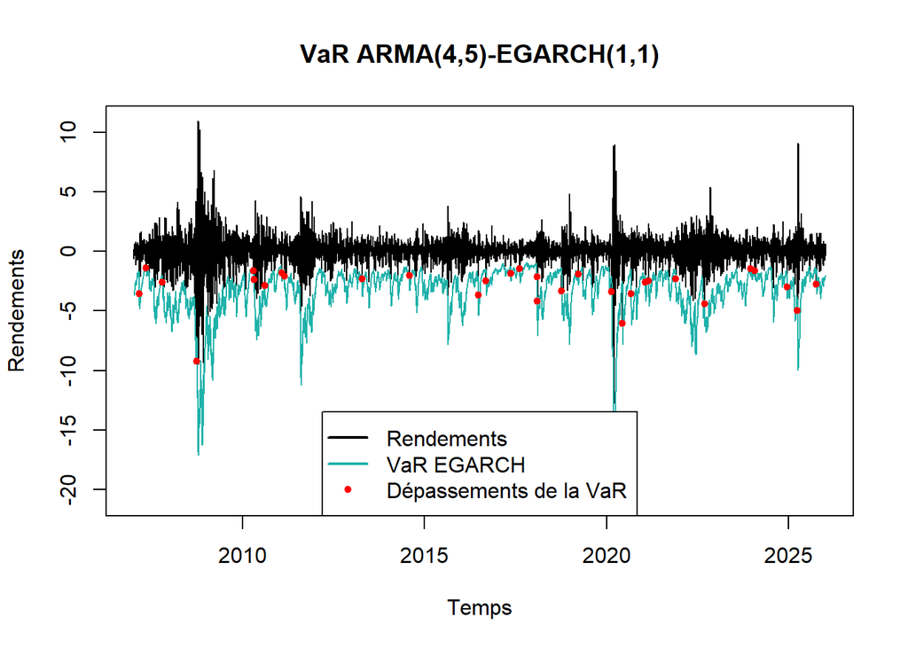

```r
# Calculer la VaR à partir du modèle EGARCH
VaR_EGARCH <- -(as.numeric(quantile(egarch11_fit, probs = 0.01)))

# Représenter les rendements et la VaR
plot(
  # Combiner dans un seul df les rendements et la VaR
  as.zoo(cbind(rend_sp_500,-VaR_EGARCH)),
  screens=1,
  col = c("black","lightseagreen"),
  main="VaR ARMA(4,5)-EGARCH(1,1)",
  xlab = "Temps",
  ylab = "Rendements"
)

# Ajouter des points lors des dépassements
points(as.zoo(rend_sp_500[as.numeric(rend_sp_500) < -VaR_EGARCH]), pch=20, col="red")

# Ajouter une légende
legend("bottom",c("Rendements","VaR EGARCH", "Dépassements de la VaR"),
         col = c("black","lightseagreen", 'red'),lty = c(1,1,NA),lwd = c(2,2,NA),pch = c(NA,NA,20))
```

On peut voir que la VaR ainsi estimé réagit bien plus vite aux variations des rendements et que les dépassements sont bien moins nombreux et semblent moins regroupés. Ils sont davantage espacés ce qui peut nous permettre d’espérer que les violations ne soient pas autocorrélées.

## Value at Risk conditionnelle (modèle GJR-GARCH)

Nous allons quand même calculer la VaR à partir du modèle GJRT-GARCH pour comparer les résultats notamment lors des tests de backtest.

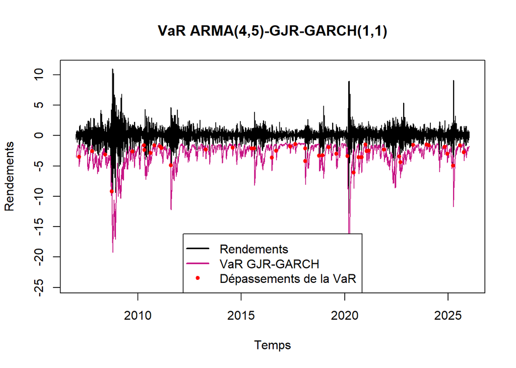

```r
# Calculer la VaR à partir du modèle GJR-GARCH
VaR_GJR <- -(as.numeric(quantile(gjr_garch11_fit, probs = 0.01)))

# Représenter les rendements et la VaR
plot(
  # Combiner dans un seul df les rendements et la VaR
  as.zoo(cbind(rend_sp_500,-VaR_GJR)),
  screens=1,
  col = c("black","mediumvioletred"),
  main="VaR ARMA(4,5)-GJR-GARCH(1,1)",
  xlab = "Temps",
  ylab = "Rendements"
)

# Ajouter des points lors des dépassements
points(as.zoo(rend_sp_500[as.numeric(rend_sp_500) < -VaR_GJR]), pch=20, col="red")

# Ajouter une légende
legend("bottom",c("Rendements","VaR GJR-GARCH", "Dépassements de la VaR"),
         col = c("black","mediumvioletred", 'red'),lty = c(1,1,NA),lwd = c(2,2,NA),pch = c(NA,NA,20))
```

IL semble que l’on observe un peu plus de violations avec cette VaR qu’avec la VaR du modèle EGARCH.

## Backtest des VaR

Nous avons différentes mesures de VaR. Il faut maintenant se décider sur celle que l’on souhaite utiliser pour modéliser le risque. Pour cela nous allons Backtester nos différentes VaR. L’idée est de vérifier si le nombre de violation correspond bien à notre taux de couverture et si ces violations ne sont pas autocorrélées entre elles.

Attention, le backtest ne peut se faire que sur un échantillon out-of-sample. Cela signifie qu’il faut estimer les paramètres de la VaR sur un échantillon initial puis l’appliquer sur l’échantillon de test (les VaR en fenêtre glissante sont une exception).

On va prendre une taille d’échantillon de test de 1000 jours. Les paramètres des VaR seront calculées sur l’échantillon total moins 1000 jours.

```r
#Création des échantillons pour estimer et tester les VaR
# Nombre de jours de l'échantillon de test : 500
nb.obs.backtest <- 1000

# Taille de l'échantillon d'estimation des paramètres de la VaR : T-500
taille.echantillon <- length(rend_sp_500)-nb.obs.backtest

# échantillon sur lequel on va estimer les paramètres de la VaR
sample_estimation <- rend_sp_500[1:taille.echantillon]

# échantillon sur lequel on va backtester la VaR
sample_backtest <- rend_sp_500[(taille.echantillon+1):length(rend_sp_500)]
```

### Bactest de la VaR historique

On va commencer par estimer la VaR historique sur l’échantillon d’estimation puis on appliquera la valeur trouvée à l’échantillon de test afin de backtester cette VaR.

```r
# Estimer la VaR historique sur l'échantillon d'estimation
VaR_historique_estimation <- -quantile(as.numeric(sample_estimation), probs=0.01) |>  print()
```

```
     1%
3.90336
```

Sur l’échantillon d’estimation la VaR historique est de 3.90% soit un peu plus que la VaR historique sur l’ensemble de l’échantillon.

Pour faire les tests de Kupiec et de Christoffersen pour tester les hypothèses de couverture non conditionnelle et conditionnelle on va utiliser la fonction `rugarch::VaRTest()` qui va prendre comme paramètres les valeurs des rendements et les valeurs de la VaR.

```r
# Tests de Kupiec et de Christoffersen sur la VaR historique en prenant l'échantillon de backtest
test_VaR_historique <-
  rugarch::VaRTest(
    alpha = 0.01, # Seuil de la VaR calculée
    actual = sample_backtest, # Echantillon de backtest
    VaR = rep(-VaR_historique_estimation, times = length(sample_backtest)), # VaR calculée : créer un vecteur de même longueur que l'échantillon de backtest car la VaR historique n'a qu'une valeur
    conf.level = 0.95 # Niveau de confiance des tests statistiques (attention pour uen fois ce n'est pas le risque)
  ) |>
  print()
```

```
$expected.exceed
[1] 10

$actual.exceed
[1] 5

$uc.H0
[1] "Correct Exceedances"

$uc.LRstat
[1] 3.093738

$uc.critical
[1] 3.841459

$uc.LRp
[1] 0.07859406

$uc.Decision
[1] "Fail to Reject H0"

$cc.H0
[1] "Correct Exceedances & Independent"

$cc.LRstat
[1] 8.930391

$cc.critical
[1] 5.991465

$cc.LRp
[1] 0.01150245

$cc.Decision
[1] "Reject H0"
```

Le résultat de la fonction se présente comme une liste où chaque élément est la valeur correspondant au nom de l’élément de la liste. Pour plus de lisibilité, on va convertir ce résultat en un tibble afin d’avoir une vue plus claire.

```r
# Convertir le résultat de backtest en un tibble
tibble(
  name = names(unlist(test_VaR_historique)), # Nom des éléments
  value = unlist(test_VaR_historique) # Résultat des éléments
) |>
  print(n = 20)
```

```
# A tibble: 12 × 2
   name            value
   <chr>           <chr>
 1 expected.exceed 10
 2 actual.exceed   5
 3 uc.H0           Correct Exceedances
 4 uc.LRstat       3.0937383140153
 5 uc.critical     3.84145882069412
 6 uc.LRp          0.0785940555397466
 7 uc.Decision     Fail to Reject H0
 8 cc.H0           Correct Exceedances & Independent
 9 cc.LRstat       8.93039131122156
10 cc.critical     5.99146454710798
11 cc.LRp          0.0115024450219067
12 cc.Decision     Reject H0
```

On peut voir que le nombre de violation devrait être de 10 (1% de 1000) mais que le nombre de dépassement observé est de 5.

Si on regarde la p.value du test de Kupiec (ligne 6), on voit que l’on ne peut pas rejeter l’hypothèse nulle de couverture non conditionnelle au seuil de 5% mais on peut le faire au seuil de 10%. Il semblerait que la VaR soit correctement calibrée sur le nombre de violations. En revanche si l’on regarde le p.value du test joint de Christoffersen (ligne 11), on voit que l’on rejette l’hypothèse de couverture conditionnelle. Si l’hypothèse de couverture non-conditionnelle n’est pas rejetée, il semblerait donc que ce soit l’indépendance des violations qui soit remise en cause. Il semblerait donc que la VaR non conditionnelle historique ne soit pas une bonne mesure de la VaR selon ces tests.

On peut tester l’hypothèse d’indépendance à des ordres supérieurs grâce à test de Ljung Box sur la fonction de violation centrée. Pour cela il faut d’abord créer cette fonction :

```r
# Créer la variable des violations
HIT <-
  if_else(
    sample_backtest < -VaR_historique_estimation, # Condition : que les rendements observés soient inférieurs à la VaR
    1, # Si la condition est vraie la variable HIT prend la valeur 1
    0 # Si la condition est fausse, la variable HIT prend la valeur 0
  )

# Créer la variable des violations centrées : soustraire le taux de couverture à la variable HIT
HIT_centre <- HIT - 0.01
```

On peut maintenant appliquer le test de Ljung-Box à l’ordre 5 (comme préconisé par les auteurs) pour tester l’hypothèse nulle d’indépendance des violations :

```r
# Test de Ljung-Box sur la variable des violations centrées : lag = 5 comme préconisé
stats::Box.test(HIT_centre, lag = 5, type = "Ljung-Box")
```

```
    Box-Ljung test

data:  HIT_centre
X-squared = 38.624, df = 5, p-value = 0.0000002827
```

On rejette l’hypothèse nulle d’indépendance des violations à l’ordre 5. La mesure de la VaR n’est aps valide car les violations ne sont pas indépendantes. Elles sont concentrées sur des périodes de crises.

On peut également faire le test DQ en régressant cette fonction de violation centrée sur les rendements et les rendements au carré (on ne peut pas régresser sur la VaR passée car la valeur est constante). Pour estimer cette régression on va utiliser la fonction `ARDL::ardl()` afin d’inclure plus facilement les 5 retards que l’on souhaite

```r
# Créer un tibble pour utiliser la fonction ardl
# Le tibble doit contenir toutes les variables utilisées dans la régression
df_ardl <-
  tibble(
    HIT_centre = HIT_centre, # Variable des violations centrée
    rend = sample_backtest, # Variable des rendements de l'échantillon de backtest
    rend2 = sample_backtest**2 # Variable des rendements au carré de l'échantillon de backtest
  )

# Estimer la régression linéaire selon un modèle ARDL avec 5 retards pour chaque variable
reg_DQ <-
  ARDL::ardl(
    HIT_centre ~ rend + rend2, # Spécification du modèle
    data = df_ardl, # Données
    order = 5 # Nombre de lags à inclure pour toutes les variables
  )

summary(reg_DQ)
```

```
Time series regression with "ts" data:
Start = 6, End = 1000

Call:
dynlm::dynlm(formula = full_formula, data = data, start = start,
    end = end)

Residuals:
     Min       1Q   Median       3Q      Max
-0.36950 -0.00750  0.00449  0.01091  0.76559

Coefficients:
                   Estimate Std. Error t value             Pr(>|t|)
(Intercept)      -0.0160617  0.0025546  -6.287       0.000000000486 ***
L(HIT_centre, 1)  0.0892092  0.0321491   2.775             0.005628 **
L(HIT_centre, 2) -0.0051852  0.0320155  -0.162             0.871373
L(HIT_centre, 3) -0.1190036  0.0324372  -3.669             0.000257 ***
L(HIT_centre, 4) -0.1147082  0.0334539  -3.429             0.000631 ***
L(HIT_centre, 5) -0.0125205  0.0335699  -0.373             0.709254
rend             -0.0187014  0.0016860 -11.092 < 0.0000000000000002 ***
L(rend, 1)        0.0010051  0.0017793   0.565             0.572282
L(rend, 2)        0.0007071  0.0017769   0.398             0.690747
L(rend, 3)        0.0024431  0.0017780   1.374             0.169731
L(rend, 4)        0.0027110  0.0017797   1.523             0.128018
L(rend, 5)       -0.0010099  0.0017802  -0.567             0.570638
rend2             0.0104698  0.0005884  17.793 < 0.0000000000000002 ***
L(rend2, 1)       0.0006227  0.0006776   0.919             0.358327
L(rend2, 2)       0.0004903  0.0006429   0.763             0.445867
L(rend2, 3)      -0.0010363  0.0005904  -1.755             0.079496 .
L(rend2, 4)      -0.0007395  0.0005896  -1.254             0.210002
L(rend2, 5)      -0.0010764  0.0005888  -1.828             0.067834 .
---
Signif. codes:  0 '***' 0.001 '**' 0.01 '*' 0.05 '.' 0.1 ' ' 1

Residual standard error: 0.05788 on 977 degrees of freedom
Multiple R-squared:  0.342, Adjusted R-squared:  0.3306
F-statistic: 29.87 on 17 and 977 DF,  p-value: < 0.00000000000000022
```

On peut voir que certains des coefficients de la régression sont statistiquement significatifs. Cela signifie que la fonction des violations centrées répond significativement à des informations disponibles dans son ensemble d’information. Il semblerait donc que l’indépendance ne soit pas respectée. Egalement, on remarque que la constante est significativement différente de 0. Cela signifie qu’il est probable que l’on observe pas assez (car constante négative) de violations pour notre taux de couverture.

Le test de significativité globale du modèle est significatif. Cela signifie que notre modèle explique globalement quelque chose. On rejette donc l’hypothèse nulle de couverture conditionnelle. Il semblerait que ce modèle de VaR ne soit pas valide.

### Bactest de la VaR normale

On va commencer par estimer la VaR normale sur l’échantillon d’estimation puis on appliquera la valeur trouvée à l’échantillon de test afin de backtester cette VaR.

```r
# Estimer la VaR normale sur l'échantillon d'estimation
VaR_normale_estimation <- -(mean(sample_estimation)+sd(sample_estimation)*qnorm(0.01)) |>  print()
```

```
[1] 2.960571
```

On effectue les tests de Kupiec et de Christoffersen pour tester les hypothèses de couverture non conditionnelle et conditionnelle.

```r
# Tests de Kupiec et de Christoffersen sur la VaR historique
test_VaR_normale <-
  rugarch::VaRTest(
    alpha = 0.01, # Taux de couverture de la VaR
    actual = sample_backtest, # Echantillon de backtest
    VaR = rep(-VaR_normale_estimation, times = length(sample_backtest)), # VaR calculée
    conf.level = 0.95 # Niveau de confiance des tests
  )

# Créer un tibble pour résumer les résultats
tibble(
  name = names(unlist(test_VaR_normale)), # Nom des éléments
  value = unlist(test_VaR_normale) # Résultat des éléments
) |>
  print(n = 20)
```

```
# A tibble: 12 × 2
   name            value
   <chr>           <chr>
 1 expected.exceed 10
 2 actual.exceed   14
 3 uc.H0           Correct Exceedances
 4 uc.LRstat       1.43740605212157
 5 uc.critical     3.84145882069412
 6 uc.LRp          0.230559559222707
 7 uc.Decision     Fail to Reject H0
 8 cc.H0           Correct Exceedances & Independent
 9 cc.LRstat       3.1832275745403
10 cc.critical     5.99146454710798
11 cc.LRp          0.203596784577842
12 cc.Decision     Fail to Reject H0
```

On peut voir que le nombre de violation devrait être de 10 (1% de 1000) mais que le nombre de dépassement observé est de 14. On a plus de violations que pour la VaR historique non conditionnelle.

Si on regarde la p.value du test de Kupiec (ligne 6), on voit que l’on ne peut pas rejeter l’hypothèse nulle de couverture non conditionnelle. Il semblerait que la VaR soit correctement calibrée sur le nombre de violations. En observant la p.value du test joint de Christoffersen (ligne 11), on voit que l’on ne peut pas rejeter l’hypothèse nulle de couverture conditionnelle. Il semblerait que nos violations soient indépendantes et que la VaR soit correctement calibrée (ce qui est un résultat étonnant).

On peut tester l’hypothèse d’indépendance à des ordres supérieurs grâce à test de Ljung Box sur la fonction de violation centrée.

```r
# Créer la variable des violations
HIT <- if_else(sample_backtest < -VaR_normale_estimation, 1, 0)

# Créer la variable des violations centrées
HIT_centre <- HIT - 0.01

# Test de Ljung Box sur les violations centrées
stats::Box.test(HIT_centre, lag = 5, type = "Ljung-Box")
```

```
    Box-Ljung test

data:  HIT_centre
X-squared = 30.783, df = 5, p-value = 0.00001034
```

On rejette l’hypothèse nulle d’indépendance des violations à l’ordre 5. La mesure de la VaR n’est pas valide car les violations ne sont pas indépendantes. Elles sont concentrées sur des périodes de crises.

On peut également faire le test DQ en régressant cette fonction de violation centrée sur les rendements et les rendements au carré (on ne peut pas régresser sur la VaR passée car la valeur est constante).

```r
# Créer un tibble pour utiliser la fonction ardl qui doit contenir toutes les données utilisées
df_ardl <-
  tibble(
    HIT_centre = HIT_centre,
    rend = sample_backtest,
    rend2 = sample_backtest**2
  )

reg_DQ <- ARDL::ardl(
  HIT_centre ~ rend + rend2,
  data = df_ardl,
  order = 5
)

summary(reg_DQ)
```

```
Time series regression with "ts" data:
Start = 6, End = 1000

Call:
dynlm::dynlm(formula = full_formula, data = data, start = start,
    end = end)

Residuals:
     Min       1Q   Median       3Q      Max
-0.74899 -0.02275  0.00502  0.02507  0.74442

Coefficients:
                   Estimate Std. Error t value             Pr(>|t|)
(Intercept)      -0.0169228  0.0035914  -4.712        0.00000280766 ***
L(HIT_centre, 1) -0.0427397  0.0320000  -1.336               0.1820
L(HIT_centre, 2)  0.0509012  0.0319780   1.592               0.1118
L(HIT_centre, 3)  0.0371995  0.0319171   1.166               0.2441
L(HIT_centre, 4) -0.0488412  0.0321349  -1.520               0.1289
L(HIT_centre, 5) -0.0088072  0.0312907  -0.281               0.7784
rend             -0.0428595  0.0025651 -16.709 < 0.0000000000000002 ***
L(rend, 1)        0.0070689  0.0029114   2.428               0.0154 *
L(rend, 2)        0.0001592  0.0029128   0.055               0.9564
L(rend, 3)        0.0069752  0.0029224   2.387               0.0172 *
L(rend, 4)       -0.0059791  0.0029260  -2.043               0.0413 *
L(rend, 5)       -0.0035556  0.0029456  -1.207               0.2277
rend2             0.0151551  0.0008547  17.732 < 0.0000000000000002 ***
L(rend2, 1)       0.0060710  0.0009927   6.115        0.00000000139 ***
L(rend2, 2)      -0.0003885  0.0009904  -0.392               0.6950
L(rend2, 3)      -0.0024627  0.0009764  -2.522               0.0118 *
L(rend2, 4)       0.0004217  0.0009793   0.431               0.6668
L(rend2, 5)      -0.0005729  0.0009807  -0.584               0.5593
---
Signif. codes:  0 '***' 0.001 '**' 0.01 '*' 0.05 '.' 0.1 ' ' 1

Residual standard error: 0.08843 on 977 degrees of freedom
Multiple R-squared:  0.4464,    Adjusted R-squared:  0.4368
F-statistic: 46.35 on 17 and 977 DF,  p-value: < 0.00000000000000022
```

On peut voir que certains des coefficients de la régression sont statistiquement significatifs. Cela signifie que la fonction des violations centrées répond significativement à des informations disponibles dans son ensemble d’information. Il semblerait donc que l’indépendance ne soit pas respectée. Egalement, on remarque que la constante est significativement différente de 0. Cela signifie qu’il est probable que l’on observe pas assez (car constante négative) de violations pour notre taux de couverture.

Le test de significativité globale du modèle est significatif. Cela signifie que notre modèle explique globalement quelque chose. On rejette donc l’hypothèse nulle de couverture conditionnelle. Il semblerait que ce modèle de VaR ne soit pas valide.

## Backtest de la VaR conditionnelle (EGARCH)

Pour backtester la VaR conditionnelle d’un modèle GARCH, il faut dans un premier temps spécifier puis estimer le modèle sur l’échantillon d’estimation. On pourra ensuite prédire (forecast) les rendements et volatilité conditionnelle pour la période $t+1$ de manière glissante. L’idée ets de prédire la valeur des rendements et de la volatilité, à partir des paramètres estimés sur l’échantillon d’estimation, pour la premier jour de l’échantillon de backtest. On prédit ensuite le jour suivant en utilisant la valeur des rendements réalisé sur le premier jour etc… (processus similaire à la validation out-of-sample vue dans le chapitre sur les ARMA). Il faut noter ici que l’on ne ré-estime pas le modèle à chaque période. On forecast en gardant toujours les mêmes paramètres que ceux estimés sur l’échantillon d’estimation.

L’étape de spécification du modèle est identique à celle vue précédemment.

```r
# Spécifier le modèle ARMA(4,5)-EGARCH(1)
egarch11_estimation_spec <-
  rugarch::ugarchspec(
    # Spécification de la variance conditionnelle
    variance.model =
      list(
        model = "eGARCH", # Utiliser un modèle GJR-GARCH
        garchOrder = c(1,1), # Ordres du GARCH(q,p)
        variance.targeting = TRUE # Définir si on veut utiliser la variance non conditionnelle empirique comme cible ou non
      ),
    # Spécification de la moyenne conditionnelle
    mean.model =
      list(
        armaOrder = c(4,5), # Ordres (p,q) du modèle ARMA
        include.mean = TRUE # Inclure une constante
      ),
    distribution.model = "sstd" # Distribution de Student asymétrique des résidus
  )
```

Pour l’estimation du modèle, il faut indiquer que l’on ne souhaite estimer les paramètres du modèle sur un sous échantillon et que l’on souhaite ainsi laisser les dernières données de côté afin d’effectuer par la suite des tests out-of-sample. Pour cela on va utiliser le paramètre `out.sample` afin d’indiquer le nombre d’observations finales que l’on souhaite laisser de coté. On va prendre ici `out.sample = 1000` pour rester cohérent avec nos échantillons de backtest pour les VaR non-conditionnelles.

```r
# Estimer le modèle
egarch11_estimation_fit <- rugarch::ugarchfit(
  egarch11_spec, # Spécification du modèle
  rend_sp_500, # Données à utiliser
  out.sample = 1000 # Nombre d'observation à laisser de coté pour les backtests
)
```

On va maintenant prédire les rendements et la volatilité de manière glissante (avec intégration des données réelles). Pour cela on utilise la fonction `rugarch::ugarchforecast()` avec le paramètre `n.roll` qui permet d’indiquer le nombre de fois que l’on veut prédire de manière glissante (ici ce sera donc 1000 pour avoir un échantillon de backtest de 1000). La fonction pour forecast peut soit prendre une spécification GARCH, auquel cas elle estimeras le modèle, ou bien elle peut prendre un modèle GARCH estimé et utiliser les paramètres déjà estimés comme des paramètres fixes pour le forecast. C’est cette deuxième option que l’on va utiliser ici.

```r
# Prédire de manière glissante les rendements et la volatilité
forecast_egarch <-
  rugarch::ugarchforecast(
    egarch11_estimation_fit, # Modèle GARCH estimé à utiliser
    data = rend_sp_500, # Données à utiliser pour les prédictions (même jeu de données que le modèle GARCH estimé)
    n.roll = 1000-1, # Nombre de glissements à effectuer.
    n.ahead = 1 # Période de forecast ici 1 jour
  )
```

On peut représenter le forecast de la volatilité conditionnelle :

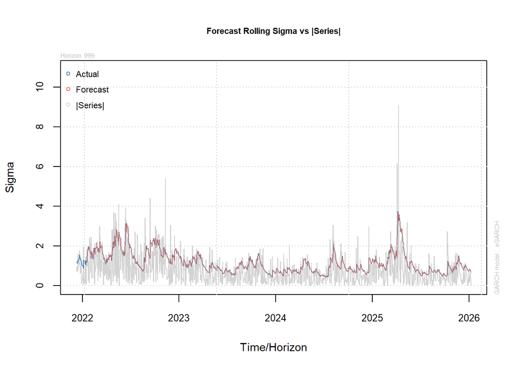

```r
# Représenter le forecast de la volatilité conditionnelle
plot(forecast_egarch, which = 4)
```

Le calcul de la VaR se fait de la même manière avec la fonction `rugarch::quantile()`.

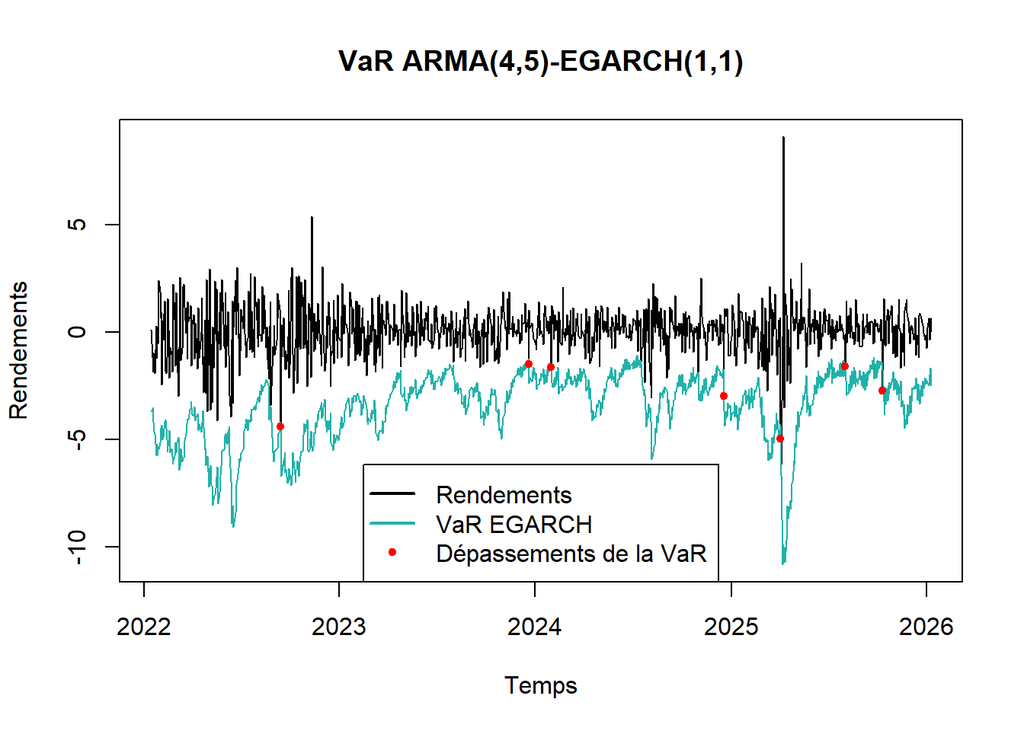

```r
# Calculer la VaR à partir du modèle EGARCH
VaR_EGARCH_backtest <- -(as.numeric(quantile(forecast_egarch, probs = 0.01)))

# Représenter les rendements et la VaR
plot(
  # Combiner dans un seul df les rendements et la VaR
  as.zoo(cbind(sample_backtest,-VaR_EGARCH_backtest)),
  screens=1,
  col = c("black","lightseagreen"),
  main="VaR ARMA(4,5)-EGARCH(1,1)",
  xlab = "Temps",
  ylab = "Rendements"
)

# Ajouter des points lors des dépassements
points(as.zoo(sample_backtest[as.numeric(sample_backtest) < -VaR_EGARCH_backtest]), pch=20, col="red")

# Ajouter une légende
legend("bottom",c("Rendements","VaR EGARCH", "Dépassements de la VaR"),
         col = c("black","lightseagreen", 'red'),lty = c(1,1,NA),lwd = c(2,2,NA),pch = c(NA,NA,20))
```

Les tests de Backtests de font de la même manière que pour les VaR inconditionnelles. On commence par les tests de Kupiec et de Christoffersen.

```r
# Tests de Kupiec et de Christoffersen sur la VaR historique
test_VaR_EGARCH<-
  rugarch::VaRTest(
    alpha = 0.01, # Taux de couverture de la VaR
    actual = sample_backtest, # Echantillon de backtest
    VaR = -VaR_EGARCH_backtest, # VaR calculée
    conf.level = 0.95 # Niveau de confiance des tests
  )

# Créer un tibble pour résumer les résultats
tibble(
  name = names(unlist(test_VaR_EGARCH)), # Nom des éléments
  value = unlist(test_VaR_EGARCH) # Résultat des éléments
) |>
  print(n = 20)
```

```
# A tibble: 12 × 2
   name            value
   <chr>           <chr>
 1 expected.exceed 10
 2 actual.exceed   7
 3 uc.H0           Correct Exceedances
 4 uc.LRstat       1.0156325251002
 5 uc.critical     3.84145882069412
 6 uc.LRp          0.313557231328653
 7 uc.Decision     Fail to Reject H0
 8 cc.H0           Correct Exceedances & Independent
 9 cc.LRstat       1.11442366754984
10 cc.critical     5.99146454710798
11 cc.LRp          0.572803911985773
12 cc.Decision     Fail to Reject H0
```

On peut voir que le nombre de violation devrait être de 10 (1% de 1000) mais que le nombre de dépassement observé est de 7.

Si on regarde la p.value du test de Kupiec (ligne 6), on voit que l’on ne peut pas rejeter l’hypothèse nulle de couverture non-conditionnelle. Il semblerait que la VaR soit correctement calibrée sur le nombre de violations. En observant la p.value du test joint de Christoffersen (ligne 11), on voit que l’on ne peut pas rejeter l’hypothèse nulle de couverture conditionnelle. Il semblerait que nos violations soient indépendantes et que la VaR soit correctement calibrée.

On peut tester l’hypothèse d’indépendance à des ordres supérieurs grâce à test de Ljung Box sur la fonction de violation centrée.

```r
# Créer la variable des violations
HIT <- if_else(sample_backtest < -VaR_EGARCH_backtest, 1, 0)

# Créer la variable des violations centrées
HIT_centre <- HIT - 0.01

# Test de Ljung Box sur les violations centrées
stats::Box.test(HIT_centre, lag = 5, type = "Ljung-Box")
```

```
    Box-Ljung test

data:  HIT_centre
X-squared = 0.25121, df = 5, p-value = 0.9985
```

On ne peut pas rejeter l’hypothèse nulle d’indépendance des violations à l’ordre 5. Il semblerait que les violations soient bien indépendantes entre elles.

On peut également faire le test DQ en régressant cette fonction de violation centrée sur les rendements et les rendements au carré (on ne peut pas régresser sur la VaR passée car la valeur est constante).

```r
# Créer un tibble pour utiliser la fonction ardl qui doit contenir toutes les données utilisées
df_ardl <-
  tibble(
    HIT_centre = HIT_centre,
    rend = sample_backtest,
    rend2 = sample_backtest**2
  )

reg_DQ <- ARDL::ardl(
  HIT_centre ~ rend + rend2,
  data = df_ardl,
  order = 5
)

summary(reg_DQ)
```

```
Time series regression with "ts" data:
Start = 6, End = 1000

Call:
dynlm::dynlm(formula = full_formula, data = data, start = start,
    end = end)

Residuals:
     Min       1Q   Median       3Q      Max
-0.26328 -0.01293 -0.00229  0.00612  0.95228

Coefficients:
                   Estimate Std. Error t value           Pr(>|t|)
(Intercept)      -0.0049927  0.0030926  -1.614             0.1068
L(HIT_centre, 1) -0.0254032  0.0321102  -0.791             0.4291
L(HIT_centre, 2)  0.0079407  0.0320774   0.248             0.8045
L(HIT_centre, 3)  0.0069794  0.0321140   0.217             0.8280
L(HIT_centre, 4) -0.0366915  0.0327323  -1.121             0.2626
L(HIT_centre, 5)  0.0141425  0.0326803   0.433             0.6653
rend             -0.0171292  0.0023118  -7.410 0.0000000000002739 ***
L(rend, 1)        0.0020079  0.0023713   0.847             0.3973
L(rend, 2)        0.0036728  0.0023630   1.554             0.1204
L(rend, 3)        0.0016793  0.0023912   0.702             0.4827
L(rend, 4)        0.0010036  0.0023974   0.419             0.6756
L(rend, 5)        0.0026863  0.0023895   1.124             0.2612
rend2             0.0061304  0.0007803   7.857 0.0000000000000104 ***
L(rend2, 1)      -0.0015398  0.0008083  -1.905             0.0571 .
L(rend2, 2)       0.0004493  0.0007833   0.574             0.5663
L(rend2, 3)      -0.0015451  0.0007722  -2.001             0.0457 *
L(rend2, 4)      -0.0003590  0.0007762  -0.463             0.6438
L(rend2, 5)      -0.0013057  0.0007723  -1.691             0.0912 .
---
Signif. codes:  0 '***' 0.001 '**' 0.01 '*' 0.05 '.' 0.1 ' ' 1

Residual standard error: 0.07961 on 977 degrees of freedom
Multiple R-squared:  0.1091,    Adjusted R-squared:  0.09362
F-statistic: 7.039 on 17 and 977 DF,  p-value: 0.0000000000000002371
```

On peut voir que certains des coefficients de la régression sont statistiquement significatifs. Cela ne concerne que les variables des rendements et rendements au carré. Il semble effectivement que les violations ne dépendent pas de leur passé. Par contre les violations semblent influencées par la valeur actuelle des rendements et par leur volatilité présente et passée. Cela indiquerait que les violations soient dans une certaine mesure prévisibles alors qu’elles ne devraient pas l’être. Cela pourrait être un motif d’invalidation de la VaR.

En revanche, la constante n’est pas significativement différente de 0. Il semble donc qu’effectivement l’hypothèse de couverture non-conditionnelle soit respectée.

Le test de significativité globale du modèle est significatif. Cela signifie que notre modèle explique globalement quelque chose. On rejette donc l’hypothèse nulle de couverture conditionnelle. Il semblerait que ce modèle de VaR ne soit pas valide selon ce test.

## Backtest de la VaR conditionnelle (GJR-GARCH)

On va backtester la VaR du modèle GJRT-GARCh pour comparer ses résultats avec celle du modèle EGARCH. On commence par spécifier le modèle GJR-GARCH.

```r
# Spécifier le modèle ARMA(4,5)-GJR-GARCH(1)
gjr_garch11_estimation_spec <-
  rugarch::ugarchspec(
    # Spécification de la variance conditionnelle
    variance.model =
      list(
        model = "gjrGARCH", # Utiliser un modèle GJR-GARCH
        garchOrder = c(1,1), # Ordres du GARCH(q,p)
        variance.targeting = TRUE # Définir si on veut utiliser la variance non conditionnelle empirique comme cible ou non
      ),
    # Spécification de la moyenne conditionnelle
    mean.model =
      list(
        armaOrder = c(4,5), # Ordres (p,q) du modèle ARMA
        include.mean = TRUE # Inclure une constante
      ),
    distribution.model = "sstd" # Distribution de Student asymétrique des résidus
  )
```

On estime ensuite le modèle en laissant de côté les 1000 dernières observations.

```r
# Estimer le modèle
gjr_garch11_estimation_fit <-
  rugarch::ugarchfit(
    gjr_garch11_estimation_spec, # Spécification du modèle
    rend_sp_500, # Données à utiliser
    out.sample = 1000 # Nombre d'observation à laisser de coté pour les backtests
  )
```

On prédit maintenant les rendements et la volatilité conditionnelle de manière glissante afin de pouvoir estimer la VaR par la suite.

```r
# Prédire de manière glissante les rendements et la volatilité
forecast_gjr_garch <-
  rugarch::ugarchforecast(
    gjr_garch11_estimation_fit, # Modèle GARCH estimé à utiliser
    data = rend_sp_500, # Données à utiliser pour les prédictions (même jeu de données que le modèle GARCH estimé)
    n.roll = 1000-1, # Nombre de glissements à effectuer. (On enlève 1 pour avoir 999 glissements + la première valeur)
    n.ahead = 1 # Période de forecast ici 1 jour
  )
```

On peut représenter le forecast de la volatilité conditionnelle :

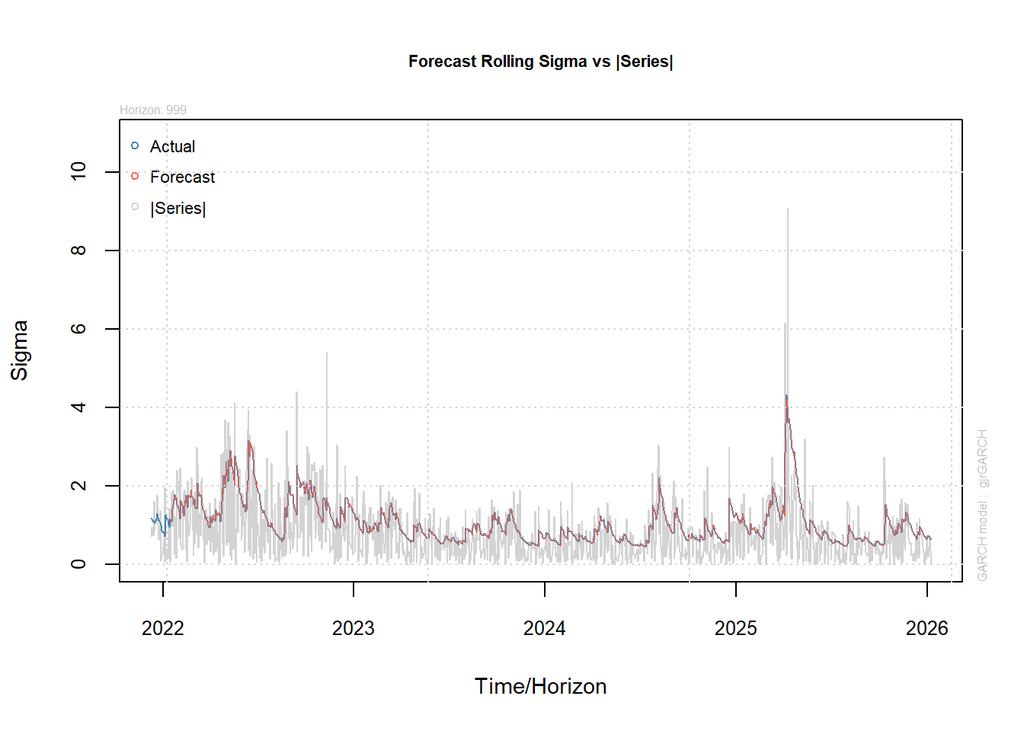

```r
# Représenter le forecast de la volatilité conditionnelle
plot(forecast_gjr_garch, which = 4)
```

On calcule maintenant la VaR de ce modèle à partir des forecast réalisés.

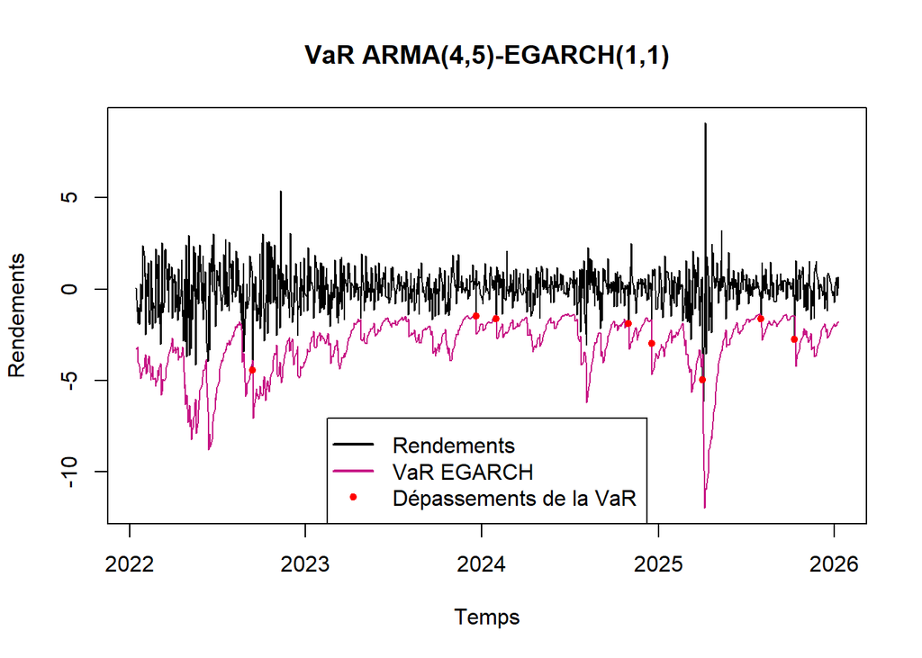

```r
# Calculer la VaR à partir du modèle EGARCH
VaR_GJR_GARCH_backtest <- -(as.numeric(quantile(forecast_gjr_garch, probs = 0.01)))

# Représenter les rendements et la VaR
plot(
  # Combiner dans un seul df les rendements et la VaR
  as.zoo(cbind(sample_backtest,-VaR_GJR_GARCH_backtest)),
  screens=1,
  col = c("black","mediumvioletred"),
  main="VaR ARMA(4,5)-EGARCH(1,1)",
  xlab = "Temps",
  ylab = "Rendements"
)

# Ajouter des points lors des dépassements
points(as.zoo(sample_backtest[as.numeric(sample_backtest) < -VaR_GJR_GARCH_backtest]), pch=20, col="red")

# Ajouter une légende
legend("bottom",c("Rendements","VaR EGARCH", "Dépassements de la VaR"),
         col = c("black","mediumvioletred", 'red'),lty = c(1,1,NA),lwd = c(2,2,NA),pch = c(NA,NA,20))
```

On commence par les tests de Kupiec et de Christoffersen.

```r
# Tests de Kupiec et de Christoffersen sur la VaR historique
test_VaR_GJR_GARCH<-
  rugarch::VaRTest(
    alpha = 0.01, # Taux de couverture de la VaR
    actual = sample_backtest, # Echantillon de backtest
    VaR = -VaR_GJR_GARCH_backtest, # VaR calculée
    conf.level = 0.95 # Niveau de confiance des tests
  )

# Créer un tibble pour résumer les résultats
tibble(
  name = names(unlist(test_VaR_GJR_GARCH)), # Nom des éléments
  value = unlist(test_VaR_GJR_GARCH) # Résultat des éléments
) |>
  print(n = 20)
```

```
# A tibble: 12 × 2
   name            value
   <chr>           <chr>
 1 expected.exceed 10
 2 actual.exceed   8
 3 uc.H0           Correct Exceedances
 4 uc.LRstat       0.433740864947217
 5 uc.critical     3.84145882069412
 6 uc.LRp          0.510159048645431
 7 uc.Decision     Fail to Reject H0
 8 cc.H0           Correct Exceedances & Independent
 9 cc.LRstat       0.562904730014249
10 cc.critical     5.99146454710798
11 cc.LRp          0.754686864322474
12 cc.Decision     Fail to Reject H0
```

On peut voir que le nombre de violation devrait être de 10 (1% de 1000) mais que le nombre de dépassement observé est de 8.

Si on regarde la p.value du test de Kupiec (ligne 6), on voit que l’on ne peut pas rejeter l’hypothèse nulle de couverture non-conditionnelle. Il semblerait que la VaR soit correctement calibrée sur le nombre de violations. En observant la p.value du test joint de Christoffersen (ligne 11), on voit que l’on ne peut pas rejeter l’hypothèse nulle de couverture conditionnelle. Il semblerait que nos violations soient indépendantes et que la VaR soit correctement calibrée.

On peut tester l’hypothèse d’indépendance à des ordres supérieurs grâce à test de Ljung Box sur la fonction de violation centrée.

```r
# Créer la variable des violations
HIT <- if_else(sample_backtest < -VaR_GJR_GARCH_backtest, 1, 0)

# Créer la variable des violations centrées
HIT_centre <- HIT - 0.01

# Test de Ljung Box sur les violations centrées
stats::Box.test(HIT_centre, lag = 5, type = "Ljung-Box")
```

```
    Box-Ljung test

data:  HIT_centre
X-squared = 0.32878, df = 5, p-value = 0.9971
```

On ne peut pas rejeter l’hypothèse nulle d’indépendance des violations à l’ordre 5. Il semblerait que les violations soient bien indépendantes entre elles.

On peut également faire le test DQ en régressant cette fonction de violation centrée sur les rendements et les rendements au carré (on ne peut pas régresser sur la VaR passée car la valeur est constante).

```r
# Créer un tibble pour utiliser la fonction ardl qui doit contenir toutes les données utilisées
df_ardl <-
  tibble(
    HIT_centre = HIT_centre,
    rend = sample_backtest,
    rend2 = sample_backtest**2
  )

reg_DQ <- ARDL::ardl(
  HIT_centre ~ rend + rend2,
  data = df_ardl,
  order = 5
)

summary(reg_DQ)
```

[output not shown]

On peut voir que certains des coefficients de la régression sont statistiquement significatifs. Cela ne concerne que les variables des rendements et rendements au carré. Il semble effectivement que les violations ne dépendent pas de leur passé. Par contre les violations semblent influencées par la valeur actuelle des rendements et par leur volatilité présente et passée. Cela indiquerait que les violations soient dans une certaine mesure prévisibles alors qu’elles ne devraient pas l’être. Cela pourrait être un motif d’invalidation de la VaR.

En revanche, la constante n’est pas significativement différente de 0. Il semble donc qu’effectivement l’hypothèse de couverture non-conditionnelle soit respectée.

Le test de significativité globale du modèle est significatif. Cela signifie que notre modèle explique globalement quelque chose. On rejette donc l’hypothèse nulle de couverture conditionnelle. Il semblerait que ce modèle de VaR ne soit pas valide selon ce test.

## Sélection du modèle de VaR

Même si aucun modèle de VaR ne passe le test DQ, les VaR conditionnelles (EGARCH et GJR-GARCH) passent les autres tests. On peut donc possiblement les considérer comme valide. La question qu’il se pose maintenant est de choisir entre ces modèles de VaR. Pour cela on va reprendre nos premières estimations de la VaR (sur l’ensemble de l’échantillon), calculer pour chaque période la moyenne de la VaR de l’ensemble de nos modèles (on va prendre tous les modèles même les non-valides pour montrer comment faire et avoir une moyenne avec plus que 2 observations) puis calculer le Biais Relatif Moyen pour voir quelle mesure de la VaR s’éloigne le moins de la moyenne.

On va commencer par créer un jeu de données qui contienne toutes les valeurs des VaR que l’on a calculé :

```r
df_VaR <-
  # Tibble avec les différentes mesures de la VaR in-sample
  tibble(
    VaR_historique = VaR_historique, # La valeur va se dupliquer toute seule
    VaR_normale = VaR_VCov,
    VaR_historique_rolling = VaR_rolling_historique |> as.numeric(), # Convertir la série temporelle en série numérique
    VaR_normale_rolling = VaR_rolling_normale |> as.numeric(),
    VaR_EGARCH = VaR_EGARCH,
    VaR_GJR = VaR_GJR
  ) |>
  drop_na() |> # Retirer les 252 premières valeurs manquantes causées par la VaR en fenêtre glissante
  print()
```

```
# A tibble: 4,534 × 6
   VaR_historique VaR_normale VaR_historique_rolling VaR_normale_rolling
            <dbl>       <dbl>                  <dbl>               <dbl>
 1           3.63        2.88                   2.83                2.34
 2           3.63        2.88                   2.83                2.38
 3           3.63        2.88                   2.83                2.38
 4           3.63        2.88                   2.83                2.40
 5           3.63        2.88                   2.83                2.40
 6           3.63        2.88                   2.83                2.40
 7           3.63        2.88                   2.83                2.42
 8           3.63        2.88                   2.83                2.42
 9           3.63        2.88                   2.83                2.46
10           3.63        2.88                   2.83                2.46
# ℹ 4,524 more rows
# ℹ 2 more variables: VaR_EGARCH <dbl>, VaR_GJR <dbl>
```

On va maintenant calculer pour chaque période de temps, la moyenne des VaR. Pour cela on va créer un nouveau jeu de données dans lequel toutes les valeurs des VaR vont être mises dans une seule colonne. Une deuxième variable indiquera le modèle de VaR et une troisième indiquera la période de temps.

```r
# Créer le dataframe servant à calculer les moyennes des VaR pour chaque période
df_VaR_long <-
  df_VaR |>
  # Ajouter une colone qui contient l'indication de la période temporelle (le numéro de ligne)
  mutate(temps = row_number()) |>
  # Pivoter le df pour mettre toutes les VaR dans une même variable
  pivot_longer(
    cols = -temps,
    names_to = "model",
    values_to = "VaR"
  ) |>
  print()
```

```
# A tibble: 27,204 × 3
   temps model                    VaR
   <int> <chr>                  <dbl>
 1     1 VaR_historique          3.63
 2     1 VaR_normale             2.88
 3     1 VaR_historique_rolling  2.83
 4     1 VaR_normale_rolling     2.34
 5     1 VaR_EGARCH              4.19
 6     1 VaR_GJR                 3.74
 7     2 VaR_historique          3.63
 8     2 VaR_normale             2.88
 9     2 VaR_historique_rolling  2.83
10     2 VaR_normale_rolling     2.38
# ℹ 27,194 more rows
```

On va maintenant pouvoir calculer la moyenne des VaR pour chaque période de temps.

```r
# Calculer la moyenne des VaR pour chaque période de temps
df_VaR_mean <-
  df_VaR_long |>
  summarize(
    .by = temps, # Grouper par temps : la moyenne sera calculée pour chaque groupe
    moyenne_VaR = mean(VaR)
  ) |>
  print()
```

```
# A tibble: 4,534 × 2
   temps moyenne_VaR
   <int>       <dbl>
 1     1        3.27
 2     2        3.21
 3     3        3.62
 4     4        3.55
 5     5        3.73
 6     6        3.66
 7     7        3.57
 8     8        3.60
 9     9        3.55
10    10        3.80
# ℹ 4,524 more rows
```

On va maintenant pouvoir calculer le BRM pour chaque modèle de VaR en comparant la valeur de sa VaR avec la valeur moyenne des VaR pour chaque période

```r
# Reprendre le jeu de données avec les VaR dans une seule variable
df_VaR_long |>
  # Fusionner avec la moyenne des VaR pour chaque période de temps
  left_join(
    df_VaR_mean,
    join_by(temps == temps)
  ) |>
  # Pour chaque observation soustraire à la VaR la moyenne des VaR de la période et diviser le tout par la moyenne des VaR de la période
  mutate(
    ecart = (VaR - moyenne_VaR) / moyenne_VaR
  ) |>
  # Pour chaque modèle calculer le MRB
  summarize(
    .by = model,
    MRB = abs(mean(ecart))
  ) |>
  print()
```

```
# A tibble: 6 × 2
  model                      MRB
  <chr>                    <dbl>
1 VaR_historique         0.246
2 VaR_normale            0.0119
3 VaR_historique_rolling 0.00887
4 VaR_normale_rolling    0.177
5 VaR_EGARCH             0.00346
6 VaR_GJR                0.0626
```

Le Biais Relatif Moyen nous indique que la VaR calculée à partir du modèle EGARCH est celle qui s’éloigne le moins de la moyenne des autres VaR. Cette mesure s’éloigne en moyenne de 0.3% de la mesure moyenne des VaR. La VaR GJR-GARCH quant à elle s’éloigne de plus de 6% en moyenne. La moins bonne VaR du point de vue de ce critère est la VaR historique qui s’éloigne en moyenne de 24.6% de la valeur moyenne des autres VaR.

On a ici inclue toutes nos VaR calculées. Il serait probablement plus rigoureux de n’inclure que que les mesures de VaR ayant été validées par les backtests s’il y en a un nombre assez conséquent.